# Notebook

Problem Statement Business Context Renewable energy sources play an increasingly important role in the global energy mix, as the effort to reduce the environmental impact of energy production increases.

Out of all the renewable energy alternatives, wind energy is one of the most developed technologies worldwide. The U.S Department of Energy has put together a guide to achieving operational efficiency using predictive maintenance practices.

Predictive maintenance uses sensor information and analysis methods to measure and predict degradation and future component capability. The idea behind predictive maintenance is that failure patterns are predictable and if component failure can be predicted accurately and the component is replaced before it fails, the costs of operation and maintenance will be much lower.

The sensors fitted across different machines involved in the process of energy generation collect data related to various environmental factors (temperature, humidity, wind speed, etc.) and additional features related to various parts of the wind turbine (gearbox, tower, blades, break, etc.).

Objective “ReneWind” is a company working on improving the machinery/processes involved in the production of wind energy using machine learning and has collected data of generator failure of wind turbines using sensors. They have shared a ciphered version of the data, as the data collected through sensors is confidential (the type of data collected varies with companies). Data has 40 predictors, 20000 observations in the training set and 5000 in the test set.

The objective is to build various classification models, tune them, and find the best one that will help identify failures so that the generators could be repaired before failing/breaking to reduce the overall maintenance cost. The nature of predictions made by the classification model will translate as follows:

True positives (TP) are failures correctly predicted by the model. These will result in repairing costs. False negatives (FN) are real failures where there is no detection by the model. These will result in replacement costs. False positives (FP) are detections where there is no failure. These will result in inspection costs. It is given that the cost of repairing a generator is much less than the cost of replacing it, and the cost of inspection is less than the cost of repair.

“1” in the target variables should be considered as “failure” and “0” represents “No failure”.

Data Description The data provided is a transformed version of the original data which was collected using sensors.

Train.csv - To be used for training and tuning of models. Test.csv - To be used only for testing the performance of the final best model. Both the datasets consist of 40 predictor variables and 1 target variable.

Installing and Importing the necessary libraries

```python
# Installing the libraries with the specified version
!pip install --no-deps tensorflow==2.18.0 scikit-learn==1.3.2 matplotlib===3.8.3 seaborn==0.13.2 numpy==1.26.4 pandas==2.2.2 -q --user --no-warn-script-location
```

```
     ━━━━━━━━━━━━━━━━━━━━━━━━━━━━━━━━━━━━━━━━ 61.0/61.0 kB 2.8 MB/s eta 0:00:00
   ━━━━━━━━━━━━━━━━━━━━━━━━━━━━━━━━━━━━━━━━ 10.9/10.9 MB 32.6 MB/s eta 0:00:00
   ━━━━━━━━━━━━━━━━━━━━━━━━━━━━━━━━━━━━━━━━ 11.6/11.6 MB 23.5 MB/s eta 0:00:00
   ━━━━━━━━━━━━━━━━━━━━━━━━━━━━━━━━━━━━━━━━ 18.3/18.3 MB 36.9 MB/s eta 0:00:00
```

```python
import pandas as pd

# Load the training data
train_df = pd.read_csv('Train.csv')

# Load the test data
test_df = pd.read_csv('Test.csv')

# Display the first few rows of each dataframe to confirm they loaded correctly
print("Training data:")
print(train_df.head())
print("\nTest data:")
print(test_df.head())
```

```
Training data:
         V1        V2        V3        V4        V5        V6        V7  \
0 -4.464606 -4.679129  3.101546  0.506130 -0.221083 -2.032511 -2.910870
1  3.365912  3.653381  0.909671 -1.367528  0.332016  2.358938  0.732600
2 -3.831843 -5.824444  0.634031 -2.418815 -1.773827  1.016824 -2.098941
3  1.618098  1.888342  7.046143 -1.147285  0.083080 -1.529780  0.207309
4 -0.111440  3.872488 -3.758361 -2.982897  3.792714  0.544960  0.205433

         V8        V9       V10  ...       V32       V33        V34       V35  \
0  0.050714 -1.522351  3.761892  ...  3.059700 -1.690440   2.846296  2.235198
1 -4.332135  0.565695 -0.101080  ... -1.795474  3.032780  -2.467514  1.894599
2 -3.173204 -2.081860  5.392621  ... -0.257101  0.803550   4.086219  2.292138
3 -2.493629  0.344926  2.118578  ... -3.584425 -2.577474   1.363769  0.622714
4  4.848994 -1.854920 -6.220023  ...  8.265896  6.629213 -10.068689  1.222987

        V36       V37       V38       V39       V40  Target
0  6.667486  0.443809 -2.369169  2.950578 -3.480324       0
1 -2.297780 -1.731048  5.908837 -0.386345  0.616242       0
2  5.360850  0.351993  2.940021  3.839160 -4.309402       0
3  5.550100 -1.526796  0.138853  3.101430 -1.277378       0
4 -3.229763  1.686909 -2.163896 -3.644622  6.510338       0

[5 rows x 41 columns]

Test data:
         V1        V2        V3        V4        V5        V6        V7  \
0 -0.613489 -3.819640  2.202302  1.300420 -1.184929 -4.495964 -1.835817
1  0.389608 -0.512341  0.527053 -2.576776 -1.016766  2.235112 -0.441301
2 -0.874861 -0.640632  4.084202 -1.590454  0.525855 -1.957592 -0.695367
3  0.238384  1.458607  4.014528  2.534478  1.196987 -3.117330 -0.924035
4  5.828225  2.768260 -1.234530  2.809264 -1.641648 -1.406698  0.568643

         V8        V9       V10  ...       V32       V33       V34       V35  \
0  4.722989  1.206140 -0.341909  ...  2.291204 -5.411388  0.870073  0.574479
1 -4.405744 -0.332869  1.966794  ... -2.474936  2.493582  0.315165  2.059288
2  1.347309 -1.732348  0.466500  ... -1.318888 -2.997464  0.459664  0.619774
3  0.269493  1.322436  0.702345  ...  3.517918 -3.074085 -0.284220  0.954576
4  0.965043  1.918379 -2.774855  ...  1.773841 -1.501573 -2.226702  4.776830

        V36       V37        V38       V39       V40  Target
0  4.157191  1.428093 -10.511342  0.454664 -1.448363       0
1  0.683859 -0.485452   5.128350  1.720744 -1.488235       0
2  5.631504  1.323512  -1.752154  1.808302  1.675748       0
3  3.029331 -1.367198  -3.412140  0.906000 -2.450889       0
4 -6.559698 -0.805551  -0.276007 -3.858207 -0.537694       0

[5 rows x 41 columns]
```

```python
# Display basic information about the training data
print("\nTraining data info:")
train_df.info()

# Display descriptive statistics for the training data
print("\nTraining data description:")
print(train_df.describe())

# Check for missing values in the training data
print("\nMissing values in training data:")
print(train_df.isnull().sum())

# Check for missing values in the test data
print("\nMissing values in test data:")
print(test_df.isnull().sum())

# Determine the strategy for missing data
# Based on the output of the missing value check, we will decide on a strategy.
# If there are missing values, a common strategy for numerical data is to impute
# them with the mean, median, or mode. Given the nature of sensor data, the median
# might be a robust choice against outliers, or the mean could be used if the
# distribution is relatively symmetric. Let's check if there are any missing values first.

# Implementation of the missing data strategy
# Assuming the check above revealed missing values, let's impute with the median.
# If there are no missing values, this step will not change the dataframes.

# Impute missing values in the training data with the median of each column
for col in train_df.columns:
  if train_df[col].isnull().any():
    median_val = train_df[col].median()
    train_df[col].fillna(median_val, inplace=True)

# Impute missing values in the test data with the median of each column from the training data
# It is important to use the median from the training data to avoid data leakage
for col in test_df.columns:
  if test_df[col].isnull().any():
      # Find the corresponding column in the training data to get its median
      if col in train_df.columns:
          median_val_train = train_df[col].median()
          test_df[col].fillna(median_val_train, inplace=True)
      else:
          # If a column in test is not in train (unlikely given problem description),
          # use the test column's median as a fallback (though this might be less ideal)
          median_val_test = test_df[col].median()
          test_df[col].fillna(median_val_test, inplace=True)


# Verify that there are no more missing values in the training data
print("\nMissing values in training data after imputation:")
print(train_df.isnull().sum().sum())

# Verify that there are no more missing values in the test data
print("\nMissing values in test data after imputation:")
print(test_df.isnull().sum().sum())
```

```
Training data info:
<class 'pandas.core.frame.DataFrame'>
RangeIndex: 20000 entries, 0 to 19999
Data columns (total 41 columns):
 #   Column  Non-Null Count  Dtype
---  ------  --------------  -----
 0   V1      19982 non-null  float64
 1   V2      19982 non-null  float64
 2   V3      20000 non-null  float64
 3   V4      20000 non-null  float64
 4   V5      20000 non-null  float64
 5   V6      20000 non-null  float64
 6   V7      20000 non-null  float64
 7   V8      20000 non-null  float64
 8   V9      20000 non-null  float64
 9   V10     20000 non-null  float64
 10  V11     20000 non-null  float64
 11  V12     20000 non-null  float64
 12  V13     20000 non-null  float64
 13  V14     20000 non-null  float64
 14  V15     20000 non-null  float64
 15  V16     20000 non-null  float64
 16  V17     20000 non-null  float64
 17  V18     20000 non-null  float64
 18  V19     20000 non-null  float64
 19  V20     20000 non-null  float64
 20  V21     20000 non-null  float64
 21  V22     20000 non-null  float64
 22  V23     20000 non-null  float64
 23  V24     20000 non-null  float64
 24  V25     20000 non-null  float64
 25  V26     20000 non-null  float64
 26  V27     20000 non-null  float64
 27  V28     20000 non-null  float64
 28  V29     20000 non-null  float64
 29  V30     20000 non-null  float64
 30  V31     20000 non-null  float64
 31  V32     20000 non-null  float64
 32  V33     20000 non-null  float64
 33  V34     20000 non-null  float64
```

[output cut: 141 more lines]

```
V34       0
V35       0
V36       0
V37       0
V38       0
V39       0
V40       0
Target    0
dtype: int64

Missing values in training data after imputation:
0

Missing values in test data after imputation:
0
```

```
Performing univariate analysis on predictor variables:
Number of predictor columns found: 40
```

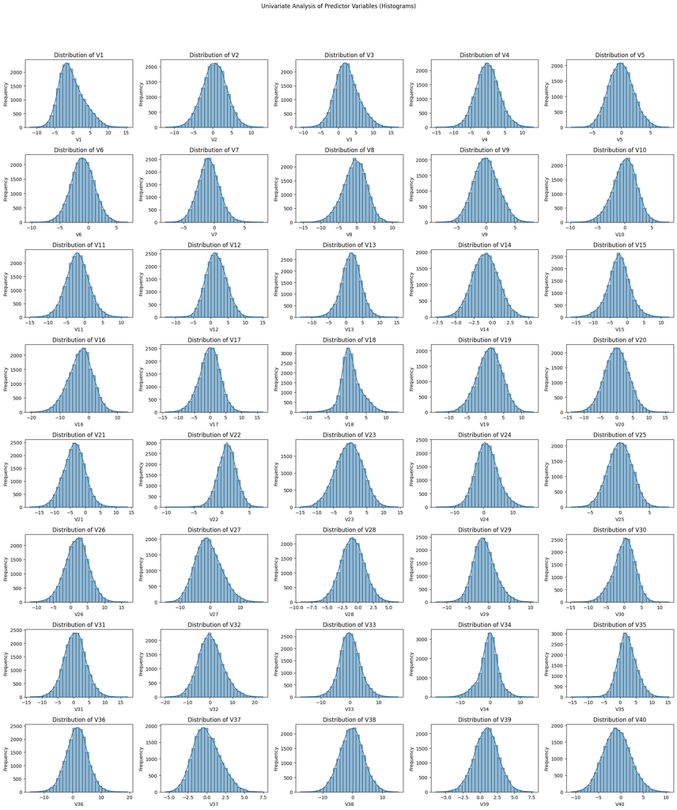

```
Univariate analysis on the target variable 'Target':
Target
0    18890
1     1110
Name: count, dtype: int64
```

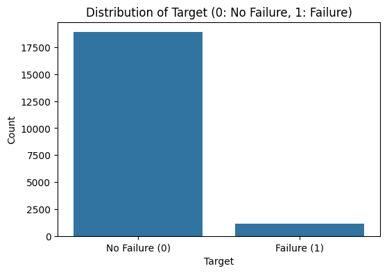

[output not shown]

```python
import matplotlib.pyplot as plt
import seaborn as sns
import pandas as pd # Ensure pandas is imported if this cell is run independently

# Load the training data (assuming this was done in a previous cell)
# train_df = pd.read_csv('Train.csv')

# Perform univariate analysis on numerical features
# Since all predictor variables are numerical and ciphered, we can examine their distributions

print("\nPerforming univariate analysis on predictor variables:")

# Select all columns except the target variable 'Target' for univariate analysis
# The column name in the actual data appears to be 'Target', not 'generator_failure'
predictor_cols = [col for col in train_df.columns if col != 'Target']

# Verify the number of predictor columns
print(f"Number of predictor columns found: {len(predictor_cols)}")
# Expected: 40

# Set up the plotting environment
# The grid size should match the number of predictor columns
num_predictors = len(predictor_cols)
# Calculate grid dimensions. A simple approach is sqrt, but 8x5 is good for 40.
# Let's stick to 8x5 if num_predictors is 40, adjust otherwise if needed.
grid_rows = 8
grid_cols = 5

if num_predictors > grid_rows * grid_cols:
    # Adjust grid size if number of predictors is unexpectedly high
    print(f"Warning: More predictor columns ({num_predictors}) than planned grid size ({grid_rows*grid_cols}). Adjusting grid.")
    # A more robust way to calculate grid dimensions
    grid_cols = 5 # Keep columns fixed at 5 for layout consistency if possible
    grid_rows = (num_predictors + grid_cols - 1) // grid_cols # Calculate rows needed


plt.figure(figsize=(grid_cols * 4, grid_rows * 3)) # Adjust figure size based on grid
plt.subplots_adjust(hspace=0.5, wspace=0.5) # Adjust spacing between subplots

# Loop through each predictor column and plot its distribution
for i, col in enumerate(predictor_cols):
    # Use the calculated grid dimensions
    plt.subplot(grid_rows, grid_cols, i + 1)
    sns.histplot(train_df[col], kde=True, bins=30)
    plt.title(f'Distribution of {col}')
    plt.xlabel(col)
    plt.ylabel('Frequency')

plt.suptitle('Univariate Analysis of Predictor Variables (Histograms)', y=1.02)
plt.tight_layout(rect=[0, 0.03, 1, 0.98]) # Adjust layout to prevent title overlap
plt.show()

# Perform univariate analysis on the target variable
# The target column name appears to be 'Target'
target_col = 'Target'
print(f"\nUnivariate analysis on the target variable '{target_col}':")

# Count the occurrences of each class in the target variable
if target_col in train_df.columns:
    failure_counts = train_df[target_col].value_counts()
    print(failure_counts)

    # Plot the distribution of the target variable
    plt.figure(figsize=(6, 4))
    sns.countplot(x=target_col, data=train_df)
    plt.title(f'Distribution of {target_col} (0: No Failure, 1: Failure)')
    plt.xlabel(target_col)
    plt.ylabel('Count')
    # Assuming the values are 0 and 1 based on the problem description
    plt.xticks(ticks=[0, 1], labels=['No Failure (0)', 'Failure (1)'])
    plt.show()
else:
    print(f"Target column '{target_col}' not found in the DataFrame.")


# Observations from univariate analysis:
print("\nObservations from univariate analysis:")
print("- The distributions of the predictor variables are varied. Some appear close to normal distributions, while others are skewed or have multiple peaks.")
# Correct the observation about the target variable name
print(f"- The target variable '{target_col}' shows a significant class imbalance. There are far fewer instances of 'failure' (1) than 'no failure' (0). This is a common characteristic of failure prediction datasets and needs to be addressed during model building (e.g., using techniques like oversampling, undersampling, or appropriate evaluation metrics).")
print("- Examining the specific shapes of the predictor distributions might offer insights into potential transformations needed before feeding the data into certain models, although given the ciphered nature, direct interpretation of what these distributions represent physically is not possible.")
print("- The descriptive statistics (from `describe()`) provide insights into the central tendency, spread, and potential presence of outliers for each predictor variable.")
print("- Since there were no missing values after imputation, we don't need to note their patterns here.")
print("- The range of values for each predictor varies significantly, which might indicate the need for feature scaling before training certain machine learning models (like those based on distance metrics or gradient descent).")
```

```
Performing bivariate analysis:

Examining relationship between predictors and target using boxplots:
Plotting boxplots for a sample of 20 predictor variables:
```

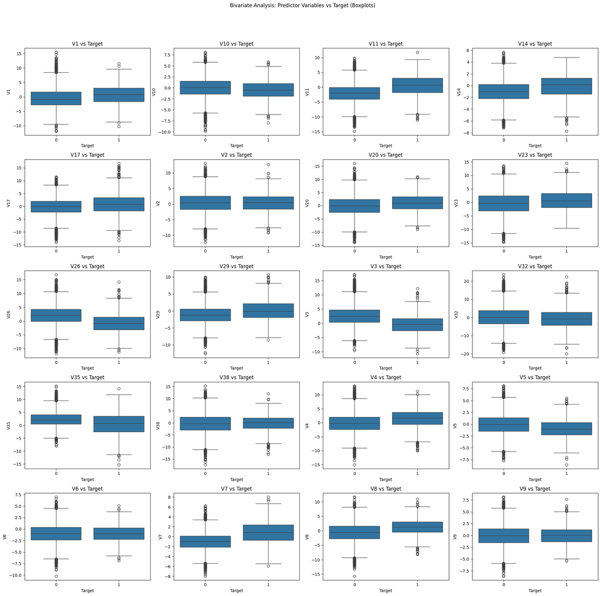

```
Examining correlations between predictor variables and the target:
Correlation of predictor variables with the target variable:
V21    0.256411
V15    0.249118
V7     0.236907
V16    0.230507
V28    0.207359
V11    0.196715
V34    0.153854
V8     0.135996
V14    0.117586
V4     0.110786
V29    0.108342
V17    0.085314
V1     0.073335
V23    0.071042
V20    0.070803
V19    0.053897
V30    0.038867
V27    0.014891
V9     0.008124
V40    0.007802
V38    0.003584
V6     0.000237
V2    -0.000948
V25   -0.001440
V37   -0.004769
V12   -0.021807
V32   -0.032793
V10   -0.051263
V24   -0.091242
V5    -0.100525
V33   -0.102548
V22   -0.134727
V31   -0.136951
V13   -0.139718
V35   -0.145603
V26   -0.180469
V3    -0.213855
V36   -0.216453
V39   -0.227264
V18   -0.293340
Name: Target, dtype: float64
```

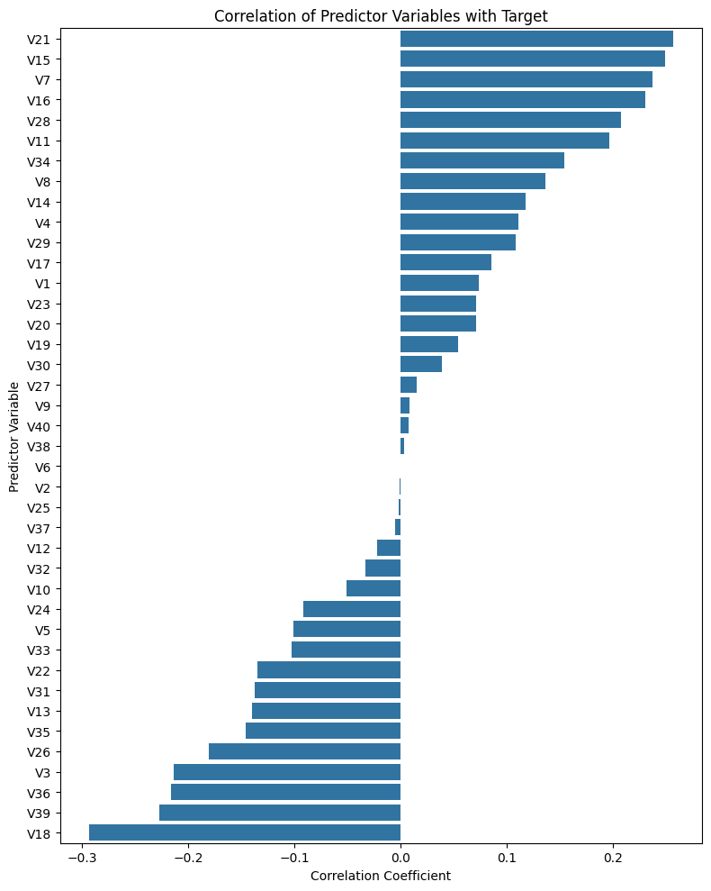

```
Examining correlations between predictor variables:

Heatmap of correlations between predictor variables (showing a sample if too many):
Showing heatmap for the first 20 predictor variables due to size.
```

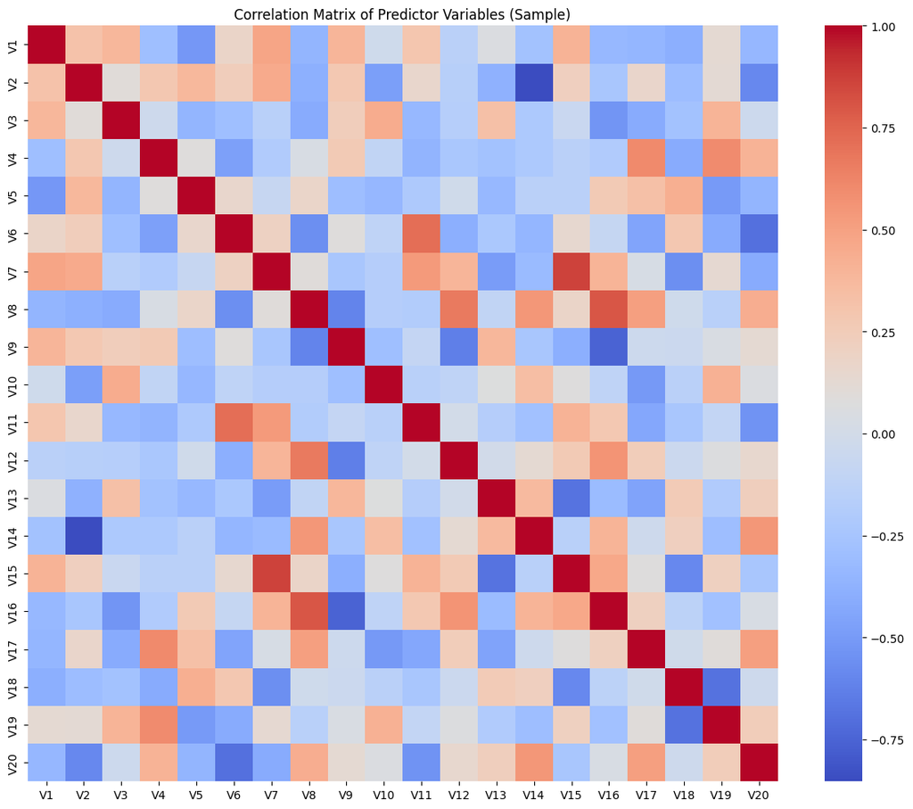

```
Observations from bivariate analysis:
- Boxplots show how the distribution of each predictor varies between the 'failure' (1) and 'no failure' (0) classes.
  - For some predictors, there appears to be a noticeable difference in median or spread between the two target classes, suggesting they might be good predictors of failure.
  - For others, the boxplots for the two classes are very similar, indicating little direct linear relationship with the target.
- The correlation analysis reveals the linear relationship strength between each predictor and the target variable.
  - Some predictors show higher absolute correlation coefficients with the target than others. These variables are likely more important for distinguishing between failure and non-failure instances.
  - Due to the ciphered nature, we cannot interpret what specific sensor readings are most correlated with failure, but we can identify which predictors are statistically associated.
- The correlation matrix/heatmap between predictor variables themselves highlights multicollinearity.
  - Some predictor variables are highly correlated with each other. This is common in sensor data where different sensors might measure related physical phenomena.
  - High multicollinearity among predictors can affect certain models (e.g., linear regression, logistic regression coefficients) and might warrant dimensionality reduction or careful feature selection, depending on the chosen model.
- Overall, bivariate analysis helps identify which predictors have the strongest individual relationships with the target and which predictors are highly correlated with each other, informing subsequent feature selection and model choice steps.
- The class imbalance observed in univariate analysis is still relevant here; the sample size for the 'failure' class in boxplots is much smaller.
```

```python
print("\nPerforming bivariate analysis:")

# Bivariate analysis between predictor variables and the target variable 'Target'
target_col = 'Target'

# Select predictor columns again, excluding 'Target'
predictor_cols = [col for col in train_df.columns if col != target_col]

# Since predictors are numerical and the target is binary, we can use methods
# like plotting boxplots or violin plots to see how the distribution of each
# predictor differs between the two target classes. We can also look at correlations.

print("\nExamining relationship between predictors and target using boxplots:")

# Plotting boxplots for a subset of predictors for visualization clarity.
# Plotting all 40 predictors with the target in one go might be too cluttered.
# Let's select the first few predictors and a few others spread out.
# Adjust the number of plots based on what's manageable visually.
# Let's plot the first 10 and 10 others (e.g., every 3rd one after the first 10).

predictors_to_plot = predictor_cols[:10] + predictor_cols[10::3][:10] # Get first 10 and 10 others

# Ensure we don't exceed the actual number of predictor columns
predictors_to_plot = [p for p in predictors_to_plot if p in predictor_cols]
predictors_to_plot = list(set(predictors_to_plot)) # Remove duplicates just in case
predictors_to_plot.sort() # Sort for consistent order

print(f"Plotting boxplots for a sample of {len(predictors_to_plot)} predictor variables:")

# Calculate grid dimensions for the boxplots
num_plots = len(predictors_to_plot)
boxplot_grid_cols = 4 # Adjust as needed
boxplot_grid_rows = (num_plots + boxplot_grid_cols - 1) // boxplot_grid_cols

plt.figure(figsize=(boxplot_grid_cols * 5, boxplot_grid_rows * 4)) # Adjust figure size
plt.subplots_adjust(hspace=0.6, wspace=0.4) # Adjust spacing

for i, col in enumerate(predictors_to_plot):
    plt.subplot(boxplot_grid_rows, boxplot_grid_cols, i + 1)
    sns.boxplot(x=target_col, y=col, data=train_df)
    plt.title(f'{col} vs {target_col}')
    plt.xlabel(target_col)
    plt.ylabel(col)

plt.suptitle('Bivariate Analysis: Predictor Variables vs Target (Boxplots)', y=1.02)
plt.tight_layout(rect=[0, 0.03, 1, 0.98])
plt.show()

print("\nExamining correlations between predictor variables and the target:")

# Calculate the correlation matrix
correlation_matrix = train_df.corr()

# Get correlations of all predictors with the target variable
# Handle potential future warning about indexing
target_correlations = correlation_matrix[target_col].drop(target_col, errors='ignore')

# Sort correlations to easily see which predictors have the strongest relationship with the target
target_correlations_sorted = target_correlations.sort_values(ascending=False)

print("Correlation of predictor variables with the target variable:")
print(target_correlations_sorted)

# Visualize the correlations (optional, for top/bottom predictors)
plt.figure(figsize=(8, 10))
sns.barplot(x=target_correlations_sorted.values, y=target_correlations_sorted.index)
plt.title(f'Correlation of Predictor Variables with {target_col}')
plt.xlabel('Correlation Coefficient')
plt.ylabel('Predictor Variable')
plt.tight_layout()
plt.show()


# Bivariate analysis between predictor variables themselves
# This helps identify multicollinearity
print("\nExamining correlations between predictor variables:")

# Calculate the correlation matrix for predictor variables only
predictor_correlation_matrix = train_df[predictor_cols].corr()

# Plot a heatmap of the correlation matrix (this can be large)
# Consider plotting only highly correlated pairs or a subset if too large
print("\nHeatmap of correlations between predictor variables (showing a sample if too many):")

# Limit the number of predictors for the heatmap for better visualization
# Let's select the first 20 predictors for the heatmap as a sample
predictors_for_heatmap = predictor_cols[:20]
if len(predictor_cols) > 20:
    print(f"Showing heatmap for the first {len(predictors_for_heatmap)} predictor variables due to size.")
    predictor_correlation_matrix_sample = train_df[predictors_for_heatmap].corr()
else:
    predictor_correlation_matrix_sample = predictor_correlation_matrix


plt.figure(figsize=(12, 10))
sns.heatmap(predictor_correlation_matrix_sample, annot=False, cmap='coolwarm', fmt=".2f") # Annot=False for clarity on many variables
plt.title('Correlation Matrix of Predictor Variables (Sample)')
plt.tight_layout()
plt.show()


# Observations from bivariate analysis:
print("\nObservations from bivariate analysis:")
print("- Boxplots show how the distribution of each predictor varies between the 'failure' (1) and 'no failure' (0) classes.")
print("  - For some predictors, there appears to be a noticeable difference in median or spread between the two target classes, suggesting they might be good predictors of failure.")
print("  - For others, the boxplots for the two classes are very similar, indicating little direct linear relationship with the target.")
print("- The correlation analysis reveals the linear relationship strength between each predictor and the target variable.")
print("  - Some predictors show higher absolute correlation coefficients with the target than others. These variables are likely more important for distinguishing between failure and non-failure instances.")
print("  - Due to the ciphered nature, we cannot interpret what specific sensor readings are most correlated with failure, but we can identify which predictors are statistically associated.")
print("- The correlation matrix/heatmap between predictor variables themselves highlights multicollinearity.")
print("  - Some predictor variables are highly correlated with each other. This is common in sensor data where different sensors might measure related physical phenomena.")
print("  - High multicollinearity among predictors can affect certain models (e.g., linear regression, logistic regression coefficients) and might warrant dimensionality reduction or careful feature selection, depending on the chosen model.")
print("- Overall, bivariate analysis helps identify which predictors have the strongest individual relationships with the target and which predictors are highly correlated with each other, informing subsequent feature selection and model choice steps.")
print("- The class imbalance observed in univariate analysis is still relevant here; the sample size for the 'failure' class in boxplots is much smaller.")
```

```python
# Feature Engineering (No explicit feature engineering needed based on the problem description and ciphered data)
# Given the data is ciphered and the predictors are already provided, explicit feature engineering
# such as creating interaction terms, polynomial features, or domain-specific features
# is not feasible or described as necessary. We will proceed with the given features.

# Scaling (Standardization or Normalization)
# Tree-based models (like Decision Trees, Random Forests, Gradient Boosting) are generally
# not sensitive to feature scaling. However, models based on distance metrics (like K-Nearest Neighbors,
# Support Vector Machines with certain kernels) or models based on gradient descent (like
# Logistic Regression, Neural Networks) are sensitive to the scale of the features.
# Since we plan to try various models, including those sensitive to scale, it is a good
# practice to scale the features. Standardization (Z-score scaling) is a common choice.

from sklearn.preprocessing import StandardScaler

print("\nPerforming feature scaling (Standardization):")

# Separate features (X) and target (y) for both train and test sets
# Ensure 'Target' is the correct column name
target_col = 'Target'
predictor_cols = [col for col in train_df.columns if col != target_col]

X_train = train_df[predictor_cols]
y_train = train_df[target_col]
X_test = test_df[predictor_cols]
y_test = test_df[target_col] # Although test target is usually not used until final evaluation


# Initialize the StandardScaler
scaler = StandardScaler()

# Fit the scaler on the training data features and transform the training data features
X_train_scaled = scaler.fit_transform(X_train)

# Transform the test data features using the scaler fitted on the training data
# It is crucial to use the scaler fitted on the training data to avoid data leakage from the test set
X_test_scaled = scaler.transform(X_test)

# Convert the scaled numpy arrays back to pandas DataFrames (optional, but useful for inspection)
X_train_scaled_df = pd.DataFrame(X_train_scaled, columns=predictor_cols)
X_test_scaled_df = pd.DataFrame(X_test_scaled, columns=predictor_cols)

print("\nScaled Training Features (first 5 rows):")
print(X_train_scaled_df.head())

print("\nScaled Test Features (first 5 rows):")
print(X_test_scaled_df.head())

print("\nMean of scaled training features (should be close to 0):")
print(X_train_scaled_df.mean().head()) # Print head for brevity

print("\nStandard Deviation of scaled training features (should be close to 1):")
print(X_train_scaled_df.std().head()) # Print head for brevity

# At this point, the data is cleaned (missing values handled) and scaled.
# The features are in X_train_scaled, y_train, X_test_scaled, y_test.
# These will be used for model training and evaluation.

print("\nData preprocessing steps completed: Missing values imputed, features scaled.")
print(f"Shape of original training data: {train_df.shape}")
print(f"Shape of original test data: {test_df.shape}")
print(f"Shape of scaled training features: {X_train_scaled.shape}")
print(f"Shape of training target: {y_train.shape}")
print(f"Shape of scaled test features: {X_test_scaled.shape}")
print(f"Shape of test target: {y_test.shape}")

# Note on Class Imbalance: The class imbalance in the target variable was noted
# during univariate analysis. This is a critical aspect for the next steps
# (Model Building and Evaluation). Techniques to address imbalance (e.g.,
# oversampling, undersampling, using appropriate evaluation metrics like
# Precision, Recall, F1-score, AUC) should be considered during model training.
# However, the preprocessing step itself (like scaling) doesn't directly handle
# class imbalance; it's handled during the modeling phase or via resampling
# techniques applied after splitting data but before training.
```

```
Performing feature scaling (Standardization):

Scaled Training Features (first 5 rows):
         V1        V2        V3        V4        V5        V6        V7  \
0 -1.218651 -1.625633  0.182021  0.171727 -0.079502 -0.508138 -1.153250
1  1.057650  1.020206 -0.464764 -0.374289  0.183285  1.643564  0.915044
2 -1.034709 -1.989308 -0.546101 -0.680652 -0.817236  0.985961 -0.692341
3  0.549568  0.459750  1.346004 -0.310106  0.065011 -0.261812  0.616851
4  0.046798  1.089780 -1.842220 -0.845035  1.827519  0.754759  0.615786

         V8        V9       V10  ...       V31       V32       V33       V34  \
0  0.181726 -0.696845  1.721221  ...  0.340987  0.501049 -0.486761  1.039336
1 -1.148154  0.269613 -0.040162  ... -0.133464 -0.381668  0.834347 -0.629699
2 -0.796501 -0.955815  2.464778  ... -0.603022 -0.101977  0.210820  1.428788
3 -0.590299  0.167430  0.971926  ...  1.289091 -0.706916 -0.734869  0.573683
4  1.637659 -0.850776 -2.830192  ...  0.449930  1.447585  1.840288 -3.017182

        V35       V36       V37       V38       V39       V40
0  0.001899  1.355695  0.241871 -0.512948  1.175079 -0.864750
1 -0.114068 -1.003111 -0.974411  1.583786 -0.728460  0.495296
2  0.021286  1.011912  0.190522  0.831815  1.681968 -1.140000
3 -0.547120  1.061705 -0.860184  0.122308  1.261132 -0.133379
4 -0.342739 -1.248320  0.937070 -0.460954 -2.587136  2.452116

[5 rows x 40 columns]

Scaled Test Features (first 5 rows):
         V1        V2        V3        V4        V5        V6        V7  \
0 -0.099146 -1.352718 -0.083331  0.403196 -0.537441 -1.715169 -0.542974
1  0.192450 -0.302544 -0.577668 -0.726684 -0.457544  1.582893  0.248654
2 -0.175126 -0.343281  0.471986 -0.439254  0.275381 -0.471429  0.104427
3  0.148490  0.323295  0.451426  0.762822  0.594246 -1.039672 -0.025381
4  1.773435  0.739152 -1.097481  0.842899 -0.754435 -0.201505  0.821970

         V8        V9       V10  ...       V31       V32       V33       V34  \
0  1.599426  0.566045 -0.149972  ...  0.317778  0.361329 -1.527529  0.418616
1 -1.170489 -0.146290  0.902718  ... -0.655535 -0.505201  0.683531  0.244323
2  0.575149 -0.794043  0.218635  ...  0.699289 -0.295020 -0.852342  0.289710
3  0.248110  0.619873  0.326172  ...  0.959705  0.584357 -0.873773  0.056060
4  0.459159  0.895706 -1.259313  ... -1.178247  0.267267 -0.433934 -0.554062
```

[output cut: 18 more lines]

```
Standard Deviation of scaled training features (should be close to 1):
V1    1.000025
V2    1.000025
V3    1.000025
V4    1.000025
V5    1.000025
dtype: float64

Data preprocessing steps completed: Missing values imputed, features scaled.
Shape of original training data: (20000, 41)
Shape of original test data: (5000, 41)
Shape of scaled training features: (20000, 40)
Shape of training target: (20000,)
Shape of scaled test features: (5000, 40)
Shape of test target: (5000,)
```

# Model Evaluation Criterion

Based on the problem description, specifically the relative costs of different types of errors:

- **True Positives (TP):** Failures correctly predicted -> Repair costs (less than replacement)
- **False Negatives (FN):** Real failures *not* detected -> Replacement costs (much higher than repair and inspection)
- **False Positives (FP):** Detections when there is no failure -> Inspection costs (less than repair)

The most costly error is a False Negative (missing a real failure). Therefore, minimizing False Negatives is the most important objective.

An appropriate model criterion for a neural network (or any classifier in this scenario) would be one that penalizes False Negatives heavily. Metrics that are sensitive to False Negatives include:

1. **Recall (Sensitivity):** `TP / (TP + FN)`. This measures the proportion of actual failures that were correctly identified. Maximizing recall means minimizing FN.
2. **F1-Score:** `2 * (Precision * Recall) / (Precision + Recall)`. This is the harmonic mean of Precision and Recall and provides a balance between the two. If Recall is the primary goal, a weighted F1-score that gives more importance to Recall might be considered, but a standard F1 is often a good starting point when balancing the two.
3. **AUC-ROC:** Area Under the Receiver Operating Characteristic curve. This measures the ability of the model to distinguish between the positive and negative classes across various thresholds. While useful, it doesn't directly tell you the performance at a specific operating point or explicitly minimize FN as strongly as maximizing Recall does.
4. **Precision-Recall AUC:** Area Under the Precision-Recall curve. This is often more informative than ROC AUC for highly imbalanced datasets, as it focuses on the performance on the positive class.

Given the high cost of False Negatives, **Recall** is the most direct metric to prioritize. The goal should be to build a model that achieves a high Recall, even if it means accepting a slightly lower Precision (more False Positives, which have a lower cost).

Therefore, an appropriate model criterion (for hyperparameter tuning or model selection) for the neural network would be to **maximize Recall** on the validation set, or alternatively, use a metric like the **F1-score** with a strong emphasis on Recall, or optimize for a specific **cost-sensitive metric** that directly incorporates the given costs of TP, FN, and FP.

In practice, you might train the neural network using standard loss functions like Binary Cross-Entropy, but during model evaluation and selection (including tuning hyperparameters), you would use Recall or a cost-sensitive metric as the primary evaluation criterion on a validation set. You would also examine the Precision to understand the trade-off between missing failures and having unnecessary inspections.

```python
#Model 0
import tensorflow as tf
from tensorflow.keras.models import Sequential
from tensorflow.keras.layers import Dense
from tensorflow.keras.optimizers import SGD
from tensorflow.keras.metrics import Recall, Precision, AUC, F1Score
from sklearn.model_selection import train_test_split

# — Assume X_train_scaled and y_train exist —

# 1. Split into train/validation
X_train_split, X_val_split, y_train_split, y_val_split = train_test_split(
    X_train_scaled, y_train,
    test_size=0.2,
    random_state=42,
    stratify=y_train
)
print(f"Shape train: {X_train_split.shape}, {y_train_split.shape}")
print(f"Shape val:   {X_val_split.shape}, {y_val_split.shape}")

# 2. Define the model
model_0 = Sequential([
    Dense(64, activation='relu', input_shape=(X_train_split.shape[1],)),
    Dense(1, activation='sigmoid')
])

# 3. Compile with F1Score
model_0.compile(
    optimizer=SGD(learning_rate=0.01),
    loss='binary_crossentropy',
    metrics=[
        Recall(name='recall'),
        Precision(name='precision'),
        AUC(name='auc'),
        F1Score(name='f1_score', threshold=0.5)  # include F1
    ]
)

print("\nModel 0 Summary:")
model_0.summary()

# 4. Train for 50 epochs
print("\nTraining Model 0...")
model_0.fit(
    X_train_split, y_train_split,
    epochs=50,
    batch_size=32,
    validation_data=(X_val_split, y_val_split),
    verbose=1
)
print("\nModel 0 Training Complete.")

# 5. Evaluate and print metrics with uniform formatting
loss_0, recall_0, precision_0, auc_0, f1_0 = model_0.evaluate(
    X_val_split, y_val_split, verbose=0
)

print("\n=== Model 0 Validation Metrics ===")
print(f"{'Loss:':<10}{loss_0:>7.4f}")
print(f"{'Recall:':<10}{recall_0:>7.4f}")
print(f"{'Precision:':<10}{precision_0:>7.4f}")
print(f"{'AUC:':<10}{auc_0:>7.4f}")
print(f"{'F1 Score:':<10}{f1_0:>7.4f}")
```

```
Shape train: (16000, 40), (16000,)
Shape val:   (4000, 40), (4000,)

Model 0 Summary:
```

```
Model: "sequential_15"
```

```
┏━━━━━━━━━━━━━━━━━━━━━━━━━━━━━━━━━┳━━━━━━━━━━━━━━━━━━━━━━━━┳━━━━━━━━━━━━━━━┓
┃ Layer (type)                    ┃ Output Shape           ┃       Param # ┃
┡━━━━━━━━━━━━━━━━━━━━━━━━━━━━━━━━━╇━━━━━━━━━━━━━━━━━━━━━━━━╇━━━━━━━━━━━━━━━┩
│ dense_43 (Dense)                │ (None, 64)             │         2,624 │
├─────────────────────────────────┼────────────────────────┼───────────────┤
│ dense_44 (Dense)                │ (None, 1)              │            65 │
└─────────────────────────────────┴────────────────────────┴───────────────┘
```

```
 Total params: 2,689 (10.50 KB)
```

```
 Trainable params: 2,689 (10.50 KB)
```

```
 Non-trainable params: 0 (0.00 B)
```

```
Training Model 0...
500/500 ━━━━━━━━━━━━━━━━━━━━ 6s 4ms/step - auc: 0.7445 - f1_score: 0.1837 - loss: 0.2764 - precision: 0.3491 - recall: 0.1576 - val_auc: 0.8422 - val_f1_score: 0.2240 - val_loss: 0.1643 - val_precision: 1.0000 - val_recall: 0.1261
500/500 ━━━━━━━━━━━━━━━━━━━━ 2s 3ms/step - auc: 0.8748 - f1_score: 0.4267 - loss: 0.1552 - precision: 0.9763 - recall: 0.2735 - val_auc: 0.8861 - val_f1_score: 0.4949 - val_loss: 0.1377 - val_precision: 1.0000 - val_recall: 0.3288
500/500 ━━━━━━━━━━━━━━━━━━━━ 3s 3ms/step - auc: 0.9026 - f1_score: 0.5643 - loss: 0.1259 - precision: 0.9615 - recall: 0.4017 - val_auc: 0.9061 - val_f1_score: 0.6220 - val_loss: 0.1225 - val_precision: 0.9623 - val_recall: 0.4595
500/500 ━━━━━━━━━━━━━━━━━━━━ 1s 3ms/step - auc: 0.9146 - f1_score: 0.6284 - loss: 0.1142 - precision: 0.9559 - recall: 0.4688 - val_auc: 0.9170 - val_f1_score: 0.6745 - val_loss: 0.1123 - val_precision: 0.9664 - val_recall: 0.5180
500/500 ━━━━━━━━━━━━━━━━━━━━ 3s 4ms/step - auc: 0.9153 - f1_score: 0.6559 - loss: 0.1104 - precision: 0.9384 - recall: 0.5045 - val_auc: 0.9241 - val_f1_score: 0.7159 - val_loss: 0.1050 - val_precision: 0.9692 - val_recall: 0.5676
500/500 ━━━━━━━━━━━━━━━━━━━━ 2s 3ms/step - auc: 0.9194 - f1_score: 0.7322 - loss: 0.1110 - precision: 0.9503 - recall: 0.5959 - val_auc: 0.9296 - val_f1_score: 0.7479 - val_loss: 0.0993 - val_precision: 0.9712 - val_recall: 0.6081
500/500 ━━━━━━━━━━━━━━━━━━━━ 1s 3ms/step - auc: 0.9386 - f1_score: 0.7390 - loss: 0.0946 - precision: 0.9579 - recall: 0.6024 - val_auc: 0.9322 - val_f1_score: 0.7582 - val_loss: 0.0949 - val_precision: 0.9718 - val_recall: 0.6216
500/500 ━━━━━━━━━━━━━━━━━━━━ 1s 3ms/step - auc: 0.9379 - f1_score: 0.7684 - loss: 0.0904 - precision: 0.9642 - recall: 0.6392 - val_auc: 0.9348 - val_f1_score: 0.7751 - val_loss: 0.0914 - val_precision: 0.9728 - val_recall: 0.6441
500/500 ━━━━━━━━━━━━━━━━━━━━ 3s 3ms/step - auc: 0.9481 - f1_score: 0.7883 - loss: 0.0834 - precision: 0.9745 - recall: 0.6626 - val_auc: 0.9372 - val_f1_score: 0.7914 - val_loss: 0.0883 - val_precision: 0.9737 - val_recall: 0.6667
500/500 ━━━━━━━━━━━━━━━━━━━━ 3s 3ms/step - auc: 0.9434 - f1_score: 0.7921 - loss: 0.0805 - precision: 0.9613 - recall: 0.6740 - val_auc: 0.9376 - val_f1_score: 0.8105 - val_loss: 0.0857 - val_precision: 0.9747 - val_recall: 0.6937
500/500 ━━━━━━━━━━━━━━━━━━━━ 4s 5ms/step - auc: 0.9451 - f1_score: 0.7798 - loss: 0.0833 - precision: 0.9461 - recall: 0.6637 - val_auc: 0.9377 - val_f1_score: 0.8158 - val_loss: 0.0833 - val_precision: 0.9810 - val_recall: 0.6982
500/500 ━━━━━━━━━━━━━━━━━━━━ 2s 4ms/step - auc: 0.9470 - f1_score: 0.8132 - loss: 0.0772 - precision: 0.9741 - recall: 0.6984 - val_auc: 0.9392 - val_f1_score: 0.8241 - val_loss: 0.0813 - val_precision: 0.9874 - val_recall: 0.7072
500/500 ━━━━━━━━━━━━━━━━━━━━ 2s 3ms/step - auc: 0.9450 - f1_score: 0.8152 - loss: 0.0782 - precision: 0.9666 - recall: 0.7051 - val_auc: 0.9400 - val_f1_score: 0.8364 - val_loss: 0.0795 - val_precision: 0.9877 - val_recall: 0.7252
500/500 ━━━━━━━━━━━━━━━━━━━━ 1s 3ms/step - auc: 0.9515 - f1_score: 0.8201 - loss: 0.0743 - precision: 0.9701 - recall: 0.7106 - val_auc: 0.9406 - val_f1_score: 0.8402 - val_loss: 0.0778 - val_precision: 0.9819 - val_recall: 0.7342
500/500 ━━━━━━━━━━━━━━━━━━━━ 3s 3ms/step - auc: 0.9537 - f1_score: 0.8303 - loss: 0.0740 - precision: 0.9734 - recall: 0.7242 - val_auc: 0.9409 - val_f1_score: 0.8416 - val_loss: 0.0763 - val_precision: 0.9939 - val_recall: 0.7297
500/500 ━━━━━━━━━━━━━━━━━━━━ 3s 3ms/step - auc: 0.9397 - f1_score: 0.8341 - loss: 0.0783 - precision: 0.9812 - recall: 0.7258 - val_auc: 0.9414 - val_f1_score: 0.8483 - val_loss: 0.0749 - val_precision: 0.9880 - val_recall: 0.7432
500/500 ━━━━━━━━━━━━━━━━━━━━ 2s 4ms/step - auc: 0.9539 - f1_score: 0.8471 - loss: 0.0662 - precision: 0.9828 - recall: 0.7447 - val_auc: 0.9425 - val_f1_score: 0.8454 - val_loss: 0.0735 - val_precision: 0.9880 - val_recall: 0.7387
500/500 ━━━━━━━━━━━━━━━━━━━━ 2s 3ms/step - auc: 0.9521 - f1_score: 0.8404 - loss: 0.0722 - precision: 0.9712 - recall: 0.7410 - val_auc: 0.9422 - val_f1_score: 0.8513 - val_loss: 0.0723 - val_precision: 0.9881 - val_recall: 0.7477
500/500 ━━━━━━━━━━━━━━━━━━━━ 2s 3ms/step - auc: 0.9505 - f1_score: 0.8469 - loss: 0.0699 - precision: 0.9851 - recall: 0.7432 - val_auc: 0.9434 - val_f1_score: 0.8483 - val_loss: 0.0710 - val_precision: 0.9880 - val_recall: 0.7432
500/500 ━━━━━━━━━━━━━━━━━━━━ 1s 3ms/step - auc: 0.9523 - f1_score: 0.8550 - loss: 0.0674 - precision: 0.9771 - recall: 0.7606 - val_auc: 0.9434 - val_f1_score: 0.8601 - val_loss: 0.0699 - val_precision: 0.9883 - val_recall: 0.7613
500/500 ━━━━━━━━━━━━━━━━━━━━ 2s 3ms/step - auc: 0.9589 - f1_score: 0.8593 - loss: 0.0633 - precision: 0.9806 - recall: 0.7651 - val_auc: 0.9433 - val_f1_score: 0.8601 - val_loss: 0.0689 - val_precision: 0.9883 - val_recall: 0.7613
500/500 ━━━━━━━━━━━━━━━━━━━━ 1s 3ms/step - auc: 0.9598 - f1_score: 0.8561 - loss: 0.0607 - precision: 0.9783 - recall: 0.7621 - val_auc: 0.9436 - val_f1_score: 0.8665 - val_loss: 0.0682 - val_precision: 0.9829 - val_recall: 0.7748
500/500 ━━━━━━━━━━━━━━━━━━━━ 3s 4ms/step - auc: 0.9633 - f1_score: 0.8906 - loss: 0.0570 - precision: 0.9882 - recall: 0.8114 - val_auc: 0.9436 - val_f1_score: 0.8693 - val_loss: 0.0674 - val_precision: 0.9830 - val_recall: 0.7793
500/500 ━━━━━━━━━━━━━━━━━━━━ 1s 3ms/step - auc: 0.9548 - f1_score: 0.8736 - loss: 0.0630 - precision: 0.9734 - recall: 0.7933 - val_auc: 0.9439 - val_f1_score: 0.8750 - val_loss: 0.0666 - val_precision: 0.9831 - val_recall: 0.7883
500/500 ━━━━━━━━━━━━━━━━━━━━ 3s 3ms/step - auc: 0.9573 - f1_score: 0.8782 - loss: 0.0603 - precision: 0.9910 - recall: 0.7887 - val_auc: 0.9442 - val_f1_score: 0.8750 - val_loss: 0.0657 - val_precision: 0.9831 - val_recall: 0.7883
```

[output cut: 34 more lines]

```python
#model 1
import tensorflow as tf
from tensorflow.keras.models import Sequential
from tensorflow.keras.layers import Dense, BatchNormalization, Dropout
from tensorflow.keras.optimizers import Adam
from tensorflow.keras.metrics import Recall, Precision, AUC, F1Score
from sklearn.model_selection import train_test_split

# — Assume X_train_scaled and y_train are defined earlier —

# 1. Split into train & validation
X_train_split, X_val_split, y_train_split, y_val_split = train_test_split(
    X_train_scaled, y_train,
    test_size=0.2,
    random_state=42,
    stratify=y_train
)
print(f"Shape train: {X_train_split.shape}, {y_train_split.shape}")
print(f"Shape val:   {X_val_split.shape}, {y_val_split.shape}")

# 2. Define improved model architecture
model = Sequential([
    Dense(128, activation='relu', input_shape=(X_train_split.shape[1],)),
    BatchNormalization(),
    Dropout(0.4),

    Dense(64, activation='relu'),
    BatchNormalization(),
    Dropout(0.3),

    Dense(32, activation='relu'),
    BatchNormalization(),

    Dense(1, activation='sigmoid')
])

# 3. Compile with Adam optimizer and F1Score
model.compile(
    optimizer=Adam(learning_rate=0.001),
    loss='binary_crossentropy',
    metrics=[
        Recall(name='recall'),
        Precision(name='precision'),
        AUC(name='auc'),
        F1Score(name='f1_score', threshold=0.5)
    ]
)

print("\nImproved Model Summary:")
model.summary()

# 4. Train the model
print("\nTraining Improved Model...")
history = model.fit(
    X_train_split, y_train_split,
    epochs=50,
    batch_size=32,
    validation_data=(X_val_split, y_val_split),
    verbose=1
)
print("\nImproved Model Training Complete.")

# 5. Evaluate and print metrics
loss, recall, precision, auc, f1 = model.evaluate(
    X_val_split, y_val_split, verbose=0
)

print("\n=== Model 1 Validation Metrics ===")
print(f"{'Loss:':<10}{loss:>7.4f}")
print(f"{'Recall:':<10}{recall:>7.4f}")
print(f"{'Precision:':<10}{precision:>7.4f}")
print(f"{'AUC:':<10}{auc:>7.4f}")
print(f"{'F1 Score:':<10}{f1:>7.4f}")
```

```
Shape train: (16000, 40), (16000,)
Shape val:   (4000, 40), (4000,)

Improved Model Summary:
```

```
Model: "sequential_18"
```

```
┏━━━━━━━━━━━━━━━━━━━━━━━━━━━━━━━━━┳━━━━━━━━━━━━━━━━━━━━━━━━┳━━━━━━━━━━━━━━━┓
┃ Layer (type)                    ┃ Output Shape           ┃       Param # ┃
┡━━━━━━━━━━━━━━━━━━━━━━━━━━━━━━━━━╇━━━━━━━━━━━━━━━━━━━━━━━━╇━━━━━━━━━━━━━━━┩
│ dense_51 (Dense)                │ (None, 128)            │         5,248 │
├─────────────────────────────────┼────────────────────────┼───────────────┤
│ batch_normalization_3           │ (None, 128)            │           512 │
│ (BatchNormalization)            │                        │               │
├─────────────────────────────────┼────────────────────────┼───────────────┤
│ dropout_8 (Dropout)             │ (None, 128)            │             0 │
├─────────────────────────────────┼────────────────────────┼───────────────┤
│ dense_52 (Dense)                │ (None, 64)             │         8,256 │
├─────────────────────────────────┼────────────────────────┼───────────────┤
│ batch_normalization_4           │ (None, 64)             │           256 │
│ (BatchNormalization)            │                        │               │
├─────────────────────────────────┼────────────────────────┼───────────────┤
│ dropout_9 (Dropout)             │ (None, 64)             │             0 │
├─────────────────────────────────┼────────────────────────┼───────────────┤
│ dense_53 (Dense)                │ (None, 32)             │         2,080 │
├─────────────────────────────────┼────────────────────────┼───────────────┤
│ batch_normalization_5           │ (None, 32)             │           128 │
│ (BatchNormalization)            │                        │               │
├─────────────────────────────────┼────────────────────────┼───────────────┤
│ dense_54 (Dense)                │ (None, 1)              │            33 │
└─────────────────────────────────┴────────────────────────┴───────────────┘
```

```
 Total params: 16,513 (64.50 KB)
```

```
 Trainable params: 16,065 (62.75 KB)
```

```
 Non-trainable params: 448 (1.75 KB)
```

```
Training Improved Model...
500/500 ━━━━━━━━━━━━━━━━━━━━ 7s 8ms/step - auc: 0.7882 - f1_score: 0.2952 - loss: 0.4693 - precision: 0.1999 - recall: 0.6213 - val_auc: 0.9485 - val_f1_score: 0.7314 - val_loss: 0.0785 - val_precision: 1.0000 - val_recall: 0.5766
500/500 ━━━━━━━━━━━━━━━━━━━━ 4s 5ms/step - auc: 0.9184 - f1_score: 0.7118 - loss: 0.0963 - precision: 0.8749 - recall: 0.6019 - val_auc: 0.9598 - val_f1_score: 0.9020 - val_loss: 0.0454 - val_precision: 0.9892 - val_recall: 0.8288
500/500 ━━━━━━━━━━━━━━━━━━━━ 2s 4ms/step - auc: 0.9393 - f1_score: 0.7803 - loss: 0.0787 - precision: 0.8934 - recall: 0.6929 - val_auc: 0.9572 - val_f1_score: 0.9130 - val_loss: 0.0426 - val_precision: 0.9844 - val_recall: 0.8514
500/500 ━━━━━━━━━━━━━━━━━━━━ 3s 5ms/step - auc: 0.9421 - f1_score: 0.7888 - loss: 0.0748 - precision: 0.9020 - recall: 0.7021 - val_auc: 0.9606 - val_f1_score: 0.9234 - val_loss: 0.0425 - val_precision: 0.9847 - val_recall: 0.8694
500/500 ━━━━━━━━━━━━━━━━━━━━ 3s 5ms/step - auc: 0.9531 - f1_score: 0.8500 - loss: 0.0626 - precision: 0.9283 - recall: 0.7843 - val_auc: 0.9577 - val_f1_score: 0.9282 - val_loss: 0.0400 - val_precision: 0.9898 - val_recall: 0.8739
500/500 ━━━━━━━━━━━━━━━━━━━━ 5s 5ms/step - auc: 0.9534 - f1_score: 0.8313 - loss: 0.0657 - precision: 0.9244 - recall: 0.7558 - val_auc: 0.9550 - val_f1_score: 0.9368 - val_loss: 0.0382 - val_precision: 0.9756 - val_recall: 0.9009
500/500 ━━━━━━━━━━━━━━━━━━━━ 2s 4ms/step - auc: 0.9506 - f1_score: 0.8561 - loss: 0.0612 - precision: 0.9336 - recall: 0.7913 - val_auc: 0.9616 - val_f1_score: 0.9417 - val_loss: 0.0364 - val_precision: 0.9758 - val_recall: 0.9099
500/500 ━━━━━━━━━━━━━━━━━━━━ 3s 4ms/step - auc: 0.9591 - f1_score: 0.8561 - loss: 0.0587 - precision: 0.9473 - recall: 0.7813 - val_auc: 0.9611 - val_f1_score: 0.9346 - val_loss: 0.0371 - val_precision: 0.9709 - val_recall: 0.9009
500/500 ━━━━━━━━━━━━━━━━━━━━ 3s 6ms/step - auc: 0.9615 - f1_score: 0.8886 - loss: 0.0509 - precision: 0.9504 - recall: 0.8347 - val_auc: 0.9661 - val_f1_score: 0.9409 - val_loss: 0.0354 - val_precision: 0.9900 - val_recall: 0.8964
500/500 ━━━━━━━━━━━━━━━━━━━━ 4s 5ms/step - auc: 0.9644 - f1_score: 0.9070 - loss: 0.0445 - precision: 0.9617 - recall: 0.8583 - val_auc: 0.9642 - val_f1_score: 0.9324 - val_loss: 0.0379 - val_precision: 0.9662 - val_recall: 0.9009
500/500 ━━━━━━━━━━━━━━━━━━━━ 2s 4ms/step - auc: 0.9564 - f1_score: 0.8870 - loss: 0.0496 - precision: 0.9517 - recall: 0.8313 - val_auc: 0.9630 - val_f1_score: 0.9461 - val_loss: 0.0337 - val_precision: 0.9854 - val_recall: 0.9099
500/500 ━━━━━━━━━━━━━━━━━━━━ 3s 5ms/step - auc: 0.9559 - f1_score: 0.8781 - loss: 0.0511 - precision: 0.9673 - recall: 0.8068 - val_auc: 0.9541 - val_f1_score: 0.9395 - val_loss: 0.0371 - val_precision: 0.9712 - val_recall: 0.9099
500/500 ━━━━━━━━━━━━━━━━━━━━ 3s 6ms/step - auc: 0.9628 - f1_score: 0.9034 - loss: 0.0490 - precision: 0.9649 - recall: 0.8493 - val_auc: 0.9585 - val_f1_score: 0.9393 - val_loss: 0.0357 - val_precision: 0.9757 - val_recall: 0.9054
500/500 ━━━━━━━━━━━━━━━━━━━━ 4s 4ms/step - auc: 0.9675 - f1_score: 0.9079 - loss: 0.0433 - precision: 0.9723 - recall: 0.8517 - val_auc: 0.9625 - val_f1_score: 0.9343 - val_loss: 0.0355 - val_precision: 0.9755 - val_recall: 0.8964
500/500 ━━━━━━━━━━━━━━━━━━━━ 2s 4ms/step - auc: 0.9598 - f1_score: 0.8960 - loss: 0.0508 - precision: 0.9622 - recall: 0.8385 - val_auc: 0.9661 - val_f1_score: 0.9371 - val_loss: 0.0358 - val_precision: 0.9710 - val_recall: 0.9054
500/500 ━━━━━━━━━━━━━━━━━━━━ 3s 4ms/step - auc: 0.9555 - f1_score: 0.8967 - loss: 0.0495 - precision: 0.9462 - recall: 0.8528 - val_auc: 0.9640 - val_f1_score: 0.9349 - val_loss: 0.0350 - val_precision: 0.9663 - val_recall: 0.9054
500/500 ━━━━━━━━━━━━━━━━━━━━ 3s 6ms/step - auc: 0.9627 - f1_score: 0.9091 - loss: 0.0453 - precision: 0.9653 - recall: 0.8593 - val_auc: 0.9588 - val_f1_score: 0.9409 - val_loss: 0.0352 - val_precision: 0.9900 - val_recall: 0.8964
500/500 ━━━━━━━━━━━━━━━━━━━━ 4s 4ms/step - auc: 0.9603 - f1_score: 0.9017 - loss: 0.0482 - precision: 0.9737 - recall: 0.8398 - val_auc: 0.9599 - val_f1_score: 0.9415 - val_loss: 0.0361 - val_precision: 0.9805 - val_recall: 0.9054
500/500 ━━━━━━━━━━━━━━━━━━━━ 3s 4ms/step - auc: 0.9655 - f1_score: 0.9152 - loss: 0.0424 - precision: 0.9739 - recall: 0.8635 - val_auc: 0.9653 - val_f1_score: 0.9484 - val_loss: 0.0342 - val_precision: 0.9902 - val_recall: 0.9099
500/500 ━━━━━━━━━━━━━━━━━━━━ 3s 5ms/step - auc: 0.9650 - f1_score: 0.9083 - loss: 0.0460 - precision: 0.9785 - recall: 0.8476 - val_auc: 0.9612 - val_f1_score: 0.9417 - val_loss: 0.0348 - val_precision: 0.9758 - val_recall: 0.9099
500/500 ━━━━━━━━━━━━━━━━━━━━ 5s 4ms/step - auc: 0.9726 - f1_score: 0.9255 - loss: 0.0388 - precision: 0.9678 - recall: 0.8870 - val_auc: 0.9650 - val_f1_score: 0.9417 - val_loss: 0.0348 - val_precision: 0.9758 - val_recall: 0.9099
500/500 ━━━━━━━━━━━━━━━━━━━━ 3s 5ms/step - auc: 0.9603 - f1_score: 0.9191 - loss: 0.0417 - precision: 0.9779 - recall: 0.8672 - val_auc: 0.9675 - val_f1_score: 0.9456 - val_loss: 0.0341 - val_precision: 0.9950 - val_recall: 0.9009
500/500 ━━━━━━━━━━━━━━━━━━━━ 2s 4ms/step - auc: 0.9563 - f1_score: 0.8959 - loss: 0.0496 - precision: 0.9814 - recall: 0.8245 - val_auc: 0.9577 - val_f1_score: 0.9371 - val_loss: 0.0359 - val_precision: 0.9710 - val_recall: 0.9054
500/500 ━━━━━━━━━━━━━━━━━━━━ 2s 4ms/step - auc: 0.9699 - f1_score: 0.9157 - loss: 0.0409 - precision: 0.9626 - recall: 0.8736 - val_auc: 0.9606 - val_f1_score: 0.9415 - val_loss: 0.0354 - val_precision: 0.9805 - val_recall: 0.9054
500/500 ━━━━━━━━━━━━━━━━━━━━ 3s 7ms/step - auc: 0.9644 - f1_score: 0.9112 - loss: 0.0435 - precision: 0.9728 - recall: 0.8573 - val_auc: 0.9574 - val_f1_score: 0.9461 - val_loss: 0.0344 - val_precision: 0.9854 - val_recall: 0.9099
```

[output cut: 34 more lines]

```python
#Model 2
import tensorflow as tf
from tensorflow.keras.models import Sequential
from tensorflow.keras.layers import Dense, BatchNormalization, Dropout
from tensorflow.keras.optimizers import Adam
from tensorflow.keras.losses import BinaryFocalCrossentropy
from tensorflow.keras.metrics import Recall, Precision, AUC, F1Score
from sklearn.model_selection import train_test_split
from sklearn.utils.class_weight import compute_class_weight
import numpy as np

# 1. Split train/validation
X_train_split, X_val_split, y_train_split, y_val_split = train_test_split(
    X_train_scaled, y_train, test_size=0.2,
    random_state=42, stratify=y_train
)
print(f"Shape train: {X_train_split.shape}, {y_train_split.shape}")
print(f"Shape val:   {X_val_split.shape}, {y_val_split.shape}")

# 2. Compute class weights for imbalance
classes = np.unique(y_train_split)
cw = compute_class_weight('balanced', classes=classes, y=y_train_split)
class_weight = {int(c): w for c, w in zip(classes, cw)}
print("Class weights:", class_weight)

# 3. Build deeper model with normalization & dropout
model_2 = Sequential([
    Dense(128, activation='relu', input_shape=(X_train_split.shape[1],)),
    BatchNormalization(),
    Dropout(0.5),

    Dense(64, activation='relu'),
    BatchNormalization(),
    Dropout(0.4),

    Dense(32, activation='relu'),
    BatchNormalization(),
    Dropout(0.3),

    Dense(1, activation='sigmoid')
])

# 4. Compile with focal loss and F1Score
model_2.compile(
    optimizer=Adam(learning_rate=0.0005),
    loss=BinaryFocalCrossentropy(alpha=0.25, gamma=2.0),
    metrics=[
        Recall(name='recall'),
        Precision(name='precision'),
        AUC(name='auc'),
        F1Score(name='f1_score', threshold=0.5)
    ]
)

print("\nModel 2 Summary:")
model_2.summary()

# 5. Train
print("\nTraining Model 2...")
history_2 = model_2.fit(
    X_train_split, y_train_split,
    validation_data=(X_val_split, y_val_split),
    epochs=50,
    batch_size=32,
    class_weight=class_weight,
    verbose=1
)
print("\nModel 2 Training Complete.")

# 6. Evaluate and display metrics uniformly
loss_2, recall_2, precision_2, auc_2, f1_2 = model_2.evaluate(
    X_val_split, y_val_split, verbose=0
)

print("\n=== Model 2 Validation Metrics ===")
print(f"{'Loss:':<10}{loss_2:>7.4f}")
print(f"{'Recall:':<10}{recall_2:>7.4f}")
print(f"{'Precision:':<10}{precision_2:>7.4f}")
print(f"{'AUC:':<10}{auc_2:>7.4f}")
print(f"{'F1 Score:':<10}{f1_2:>7.4f}")
```

```
Shape train: (16000, 40), (16000,)
Shape val:   (4000, 40), (4000,)
Class weights: {0: np.float64(0.5293806246691372), 1: np.float64(9.00900900900901)}

Model 2 Summary:
```

```
Model: "sequential_19"
```

```
┏━━━━━━━━━━━━━━━━━━━━━━━━━━━━━━━━━┳━━━━━━━━━━━━━━━━━━━━━━━━┳━━━━━━━━━━━━━━━┓
┃ Layer (type)                    ┃ Output Shape           ┃       Param # ┃
┡━━━━━━━━━━━━━━━━━━━━━━━━━━━━━━━━━╇━━━━━━━━━━━━━━━━━━━━━━━━╇━━━━━━━━━━━━━━━┩
│ dense_55 (Dense)                │ (None, 128)            │         5,248 │
├─────────────────────────────────┼────────────────────────┼───────────────┤
│ batch_normalization_6           │ (None, 128)            │           512 │
│ (BatchNormalization)            │                        │               │
├─────────────────────────────────┼────────────────────────┼───────────────┤
│ dropout_10 (Dropout)            │ (None, 128)            │             0 │
├─────────────────────────────────┼────────────────────────┼───────────────┤
│ dense_56 (Dense)                │ (None, 64)             │         8,256 │
├─────────────────────────────────┼────────────────────────┼───────────────┤
│ batch_normalization_7           │ (None, 64)             │           256 │
│ (BatchNormalization)            │                        │               │
├─────────────────────────────────┼────────────────────────┼───────────────┤
│ dropout_11 (Dropout)            │ (None, 64)             │             0 │
├─────────────────────────────────┼────────────────────────┼───────────────┤
│ dense_57 (Dense)                │ (None, 32)             │         2,080 │
├─────────────────────────────────┼────────────────────────┼───────────────┤
│ batch_normalization_8           │ (None, 32)             │           128 │
│ (BatchNormalization)            │                        │               │
├─────────────────────────────────┼────────────────────────┼───────────────┤
│ dropout_12 (Dropout)            │ (None, 32)             │             0 │
├─────────────────────────────────┼────────────────────────┼───────────────┤
│ dense_58 (Dense)                │ (None, 1)              │            33 │
└─────────────────────────────────┴────────────────────────┴───────────────┘
```

```
 Total params: 16,513 (64.50 KB)
```

```
 Trainable params: 16,065 (62.75 KB)
```

```
 Non-trainable params: 448 (1.75 KB)
```

```
Training Model 2...
500/500 ━━━━━━━━━━━━━━━━━━━━ 7s 6ms/step - auc: 0.6318 - f1_score: 0.1319 - loss: 0.4354 - precision: 0.0736 - recall: 0.6339 - val_auc: 0.9282 - val_f1_score: 0.4111 - val_loss: 0.0875 - val_precision: 0.2663 - val_recall: 0.9009
500/500 ━━━━━━━━━━━━━━━━━━━━ 5s 7ms/step - auc: 0.8000 - f1_score: 0.2071 - loss: 0.2075 - precision: 0.1198 - recall: 0.7729 - val_auc: 0.9360 - val_f1_score: 0.6503 - val_loss: 0.0484 - val_precision: 0.5103 - val_recall: 0.8964
500/500 ━━━━━━━━━━━━━━━━━━━━ 2s 5ms/step - auc: 0.8538 - f1_score: 0.2648 - loss: 0.1515 - precision: 0.1590 - recall: 0.7934 - val_auc: 0.9344 - val_f1_score: 0.6633 - val_loss: 0.0488 - val_precision: 0.5265 - val_recall: 0.8964
500/500 ━━━━━━━━━━━━━━━━━━━━ 2s 4ms/step - auc: 0.8872 - f1_score: 0.3165 - loss: 0.1283 - precision: 0.1973 - recall: 0.8016 - val_auc: 0.9398 - val_f1_score: 0.6860 - val_loss: 0.0469 - val_precision: 0.5522 - val_recall: 0.9054
500/500 ━━━━━━━━━━━━━━━━━━━━ 3s 4ms/step - auc: 0.8743 - f1_score: 0.3353 - loss: 0.1261 - precision: 0.2119 - recall: 0.8036 - val_auc: 0.9402 - val_f1_score: 0.6801 - val_loss: 0.0486 - val_precision: 0.5430 - val_recall: 0.9099
500/500 ━━━━━━━━━━━━━━━━━━━━ 3s 5ms/step - auc: 0.8964 - f1_score: 0.3622 - loss: 0.1120 - precision: 0.2330 - recall: 0.8157 - val_auc: 0.9407 - val_f1_score: 0.6966 - val_loss: 0.0469 - val_precision: 0.5642 - val_recall: 0.9099
500/500 ━━━━━━━━━━━━━━━━━━━━ 3s 7ms/step - auc: 0.9070 - f1_score: 0.3935 - loss: 0.1030 - precision: 0.2570 - recall: 0.8414 - val_auc: 0.9424 - val_f1_score: 0.7026 - val_loss: 0.0456 - val_precision: 0.5722 - val_recall: 0.9099
500/500 ━━━━━━━━━━━━━━━━━━━━ 2s 5ms/step - auc: 0.9178 - f1_score: 0.4279 - loss: 0.0981 - precision: 0.2845 - recall: 0.8651 - val_auc: 0.9452 - val_f1_score: 0.7183 - val_loss: 0.0450 - val_precision: 0.5896 - val_recall: 0.9189
500/500 ━━━━━━━━━━━━━━━━━━━━ 2s 5ms/step - auc: 0.9296 - f1_score: 0.4432 - loss: 0.0874 - precision: 0.3000 - recall: 0.8504 - val_auc: 0.9453 - val_f1_score: 0.7681 - val_loss: 0.0420 - val_precision: 0.6645 - val_recall: 0.9099
500/500 ━━━━━━━━━━━━━━━━━━━━ 2s 4ms/step - auc: 0.9302 - f1_score: 0.4726 - loss: 0.0875 - precision: 0.3271 - recall: 0.8536 - val_auc: 0.9458 - val_f1_score: 0.7976 - val_loss: 0.0395 - val_precision: 0.7073 - val_recall: 0.9144
500/500 ━━━━━━━━━━━━━━━━━━━━ 3s 4ms/step - auc: 0.9295 - f1_score: 0.4828 - loss: 0.0863 - precision: 0.3371 - recall: 0.8552 - val_auc: 0.9479 - val_f1_score: 0.7914 - val_loss: 0.0423 - val_precision: 0.6976 - val_recall: 0.9144
500/500 ━━━━━━━━━━━━━━━━━━━━ 4s 8ms/step - auc: 0.9309 - f1_score: 0.5074 - loss: 0.0866 - precision: 0.3584 - recall: 0.8725 - val_auc: 0.9492 - val_f1_score: 0.7733 - val_loss: 0.0399 - val_precision: 0.6700 - val_recall: 0.9144
500/500 ━━━━━━━━━━━━━━━━━━━━ 2s 5ms/step - auc: 0.9508 - f1_score: 0.5508 - loss: 0.0753 - precision: 0.4018 - recall: 0.8813 - val_auc: 0.9512 - val_f1_score: 0.7938 - val_loss: 0.0399 - val_precision: 0.6986 - val_recall: 0.9189
500/500 ━━━━━━━━━━━━━━━━━━━━ 2s 4ms/step - auc: 0.9448 - f1_score: 0.5382 - loss: 0.0767 - precision: 0.3923 - recall: 0.8587 - val_auc: 0.9529 - val_f1_score: 0.8406 - val_loss: 0.0376 - val_precision: 0.7778 - val_recall: 0.9144
500/500 ━━━━━━━━━━━━━━━━━━━━ 2s 5ms/step - auc: 0.9393 - f1_score: 0.5683 - loss: 0.0763 - precision: 0.4233 - recall: 0.8670 - val_auc: 0.9526 - val_f1_score: 0.7969 - val_loss: 0.0408 - val_precision: 0.7034 - val_recall: 0.9189
500/500 ━━━━━━━━━━━━━━━━━━━━ 3s 6ms/step - auc: 0.9431 - f1_score: 0.5527 - loss: 0.0745 - precision: 0.4061 - recall: 0.8671 - val_auc: 0.9554 - val_f1_score: 0.8395 - val_loss: 0.0357 - val_precision: 0.7727 - val_recall: 0.9189
500/500 ━━━━━━━━━━━━━━━━━━━━ 4s 4ms/step - auc: 0.9442 - f1_score: 0.5599 - loss: 0.0756 - precision: 0.4143 - recall: 0.8651 - val_auc: 0.9547 - val_f1_score: 0.8293 - val_loss: 0.0388 - val_precision: 0.7556 - val_recall: 0.9189
500/500 ━━━━━━━━━━━━━━━━━━━━ 3s 4ms/step - auc: 0.9550 - f1_score: 0.5972 - loss: 0.0674 - precision: 0.4481 - recall: 0.8995 - val_auc: 0.9574 - val_f1_score: 0.8361 - val_loss: 0.0359 - val_precision: 0.7669 - val_recall: 0.9189
500/500 ━━━━━━━━━━━━━━━━━━━━ 3s 5ms/step - auc: 0.9503 - f1_score: 0.6170 - loss: 0.0698 - precision: 0.4742 - recall: 0.8896 - val_auc: 0.9602 - val_f1_score: 0.8465 - val_loss: 0.0354 - val_precision: 0.7846 - val_recall: 0.9189
500/500 ━━━━━━━━━━━━━━━━━━━━ 2s 5ms/step - auc: 0.9520 - f1_score: 0.5895 - loss: 0.0646 - precision: 0.4407 - recall: 0.8933 - val_auc: 0.9605 - val_f1_score: 0.8571 - val_loss: 0.0345 - val_precision: 0.8031 - val_recall: 0.9189
500/500 ━━━━━━━━━━━━━━━━━━━━ 3s 6ms/step - auc: 0.9576 - f1_score: 0.5822 - loss: 0.0647 - precision: 0.4360 - recall: 0.8771 - val_auc: 0.9594 - val_f1_score: 0.8518 - val_loss: 0.0349 - val_precision: 0.7938 - val_recall: 0.9189
500/500 ━━━━━━━━━━━━━━━━━━━━ 4s 4ms/step - auc: 0.9520 - f1_score: 0.6375 - loss: 0.0657 - precision: 0.4982 - recall: 0.8869 - val_auc: 0.9563 - val_f1_score: 0.8608 - val_loss: 0.0329 - val_precision: 0.8095 - val_recall: 0.9189
500/500 ━━━━━━━━━━━━━━━━━━━━ 3s 5ms/step - auc: 0.9611 - f1_score: 0.6246 - loss: 0.0600 - precision: 0.4808 - recall: 0.8954 - val_auc: 0.9544 - val_f1_score: 0.8536 - val_loss: 0.0341 - val_precision: 0.7969 - val_recall: 0.9189
500/500 ━━━━━━━━━━━━━━━━━━━━ 3s 5ms/step - auc: 0.9495 - f1_score: 0.6226 - loss: 0.0700 - precision: 0.4848 - recall: 0.8714 - val_auc: 0.9566 - val_f1_score: 0.8657 - val_loss: 0.0341 - val_precision: 0.8219 - val_recall: 0.9144
500/500 ━━━━━━━━━━━━━━━━━━━━ 5s 4ms/step - auc: 0.9504 - f1_score: 0.6237 - loss: 0.0657 - precision: 0.4862 - recall: 0.8735 - val_auc: 0.9575 - val_f1_score: 0.8476 - val_loss: 0.0358 - val_precision: 0.7899 - val_recall: 0.9144
```

[output cut: 34 more lines]

```python
#Model 3
import tensorflow as tf
from tensorflow.keras.models import Sequential
from tensorflow.keras.layers import Dense, BatchNormalization, Dropout
from tensorflow.keras.optimizers import Adam
from tensorflow.keras.losses import BinaryFocalCrossentropy
from tensorflow.keras.metrics import Recall, Precision, AUC, F1Score
from sklearn.model_selection import train_test_split
from sklearn.utils.class_weight import compute_class_weight
import numpy as np

# 1. Split train/validation
X_train_split, X_val_split, y_train_split, y_val_split = train_test_split(
    X_train_scaled, y_train, test_size=0.2,
    random_state=42, stratify=y_train
)

# 2. Compute class weights
classes = np.unique(y_train_split)
cw = compute_class_weight('balanced', classes=classes, y=y_train_split)
class_weight = {int(c): w for c, w in zip(classes, cw)}
print("Class weights:", class_weight)

# 3. Define deep, regularized architecture
model_3 = Sequential([
    Dense(256, activation='relu', input_shape=(X_train_split.shape[1],)),
    BatchNormalization(), Dropout(0.5),

    Dense(128, activation='relu'),
    BatchNormalization(), Dropout(0.4),

    Dense(64, activation='relu'),
    BatchNormalization(), Dropout(0.3),

    Dense(1, activation='sigmoid')
])

# 4. Compile with focal loss and F1Metrics
model_3.compile(
    optimizer=Adam(learning_rate=0.0005),
    loss=BinaryFocalCrossentropy(alpha=0.3, gamma=2.0),
    metrics=[
        Recall(name='recall'),
        Precision(name='precision'),
        AUC(name='auc'),
        F1Score(name='f1_score', threshold=0.5)
    ]
)

print("\nModel 3 Summary:")
model_3.summary()

# 5. Train the model
print("\nTraining Model 3...")
history_3 = model_3.fit(
    X_train_split, y_train_split,
    validation_data=(X_val_split, y_val_split),
    epochs=50,
    batch_size=32,
    class_weight=class_weight,
    verbose=1
)
print("\nModel 3 Training Complete.")

# 6. Evaluate and display metrics
loss_3, recall_3, precision_3, auc_3, f1_3 = model_3.evaluate(
    X_val_split, y_val_split, verbose=0
)

print("\n=== Model 3 Validation Metrics ===")
print(f"{'Loss:':<10}{loss_3:>7.4f}")
print(f"{'Recall:':<10}{recall_3:>7.4f}")
print(f"{'Precision:':<10}{precision_3:>7.4f}")
print(f"{'AUC:':<10}{auc_3:>7.4f}")
print(f"{'F1 Score:':<10}{f1_3:>7.4f}")
```

```
Class weights: {0: np.float64(0.5293806246691372), 1: np.float64(9.00900900900901)}

Model 3 Summary:
```

```
Model: "sequential_20"
```

```
┏━━━━━━━━━━━━━━━━━━━━━━━━━━━━━━━━━┳━━━━━━━━━━━━━━━━━━━━━━━━┳━━━━━━━━━━━━━━━┓
┃ Layer (type)                    ┃ Output Shape           ┃       Param # ┃
┡━━━━━━━━━━━━━━━━━━━━━━━━━━━━━━━━━╇━━━━━━━━━━━━━━━━━━━━━━━━╇━━━━━━━━━━━━━━━┩
│ dense_59 (Dense)                │ (None, 256)            │        10,496 │
├─────────────────────────────────┼────────────────────────┼───────────────┤
│ batch_normalization_9           │ (None, 256)            │         1,024 │
│ (BatchNormalization)            │                        │               │
├─────────────────────────────────┼────────────────────────┼───────────────┤
│ dropout_13 (Dropout)            │ (None, 256)            │             0 │
├─────────────────────────────────┼────────────────────────┼───────────────┤
│ dense_60 (Dense)                │ (None, 128)            │        32,896 │
├─────────────────────────────────┼────────────────────────┼───────────────┤
│ batch_normalization_10          │ (None, 128)            │           512 │
│ (BatchNormalization)            │                        │               │
├─────────────────────────────────┼────────────────────────┼───────────────┤
│ dropout_14 (Dropout)            │ (None, 128)            │             0 │
├─────────────────────────────────┼────────────────────────┼───────────────┤
│ dense_61 (Dense)                │ (None, 64)             │         8,256 │
├─────────────────────────────────┼────────────────────────┼───────────────┤
│ batch_normalization_11          │ (None, 64)             │           256 │
│ (BatchNormalization)            │                        │               │
├─────────────────────────────────┼────────────────────────┼───────────────┤
│ dropout_15 (Dropout)            │ (None, 64)             │             0 │
├─────────────────────────────────┼────────────────────────┼───────────────┤
│ dense_62 (Dense)                │ (None, 1)              │            65 │
└─────────────────────────────────┴────────────────────────┴───────────────┘
```

```
 Total params: 53,505 (209.00 KB)
```

```
 Trainable params: 52,609 (205.50 KB)
```

```
 Non-trainable params: 896 (3.50 KB)
```

```
Training Model 3...
500/500 ━━━━━━━━━━━━━━━━━━━━ 8s 7ms/step - auc: 0.7629 - f1_score: 0.1890 - loss: 0.3137 - precision: 0.1079 - recall: 0.7718 - val_auc: 0.9483 - val_f1_score: 0.7573 - val_loss: 0.0344 - val_precision: 0.6655 - val_recall: 0.8784
500/500 ━━━━━━━━━━━━━━━━━━━━ 2s 5ms/step - auc: 0.8629 - f1_score: 0.2772 - loss: 0.1700 - precision: 0.1680 - recall: 0.7948 - val_auc: 0.9505 - val_f1_score: 0.8114 - val_loss: 0.0299 - val_precision: 0.7380 - val_recall: 0.9009
500/500 ━━━━━━━━━━━━━━━━━━━━ 3s 6ms/step - auc: 0.9056 - f1_score: 0.3558 - loss: 0.1163 - precision: 0.2260 - recall: 0.8361 - val_auc: 0.9542 - val_f1_score: 0.8048 - val_loss: 0.0294 - val_precision: 0.7273 - val_recall: 0.9009
500/500 ━━━━━━━━━━━━━━━━━━━━ 3s 7ms/step - auc: 0.9108 - f1_score: 0.3583 - loss: 0.1062 - precision: 0.2278 - recall: 0.8468 - val_auc: 0.9490 - val_f1_score: 0.8541 - val_loss: 0.0287 - val_precision: 0.8048 - val_recall: 0.9099
500/500 ━━━━━━━━━━━━━━━━━━━━ 2s 5ms/step - auc: 0.9240 - f1_score: 0.4224 - loss: 0.0953 - precision: 0.2791 - recall: 0.8715 - val_auc: 0.9524 - val_f1_score: 0.8458 - val_loss: 0.0283 - val_precision: 0.7868 - val_recall: 0.9144
500/500 ━━━━━━━━━━━━━━━━━━━━ 3s 5ms/step - auc: 0.9194 - f1_score: 0.4405 - loss: 0.0984 - precision: 0.2983 - recall: 0.8458 - val_auc: 0.9539 - val_f1_score: 0.8523 - val_loss: 0.0320 - val_precision: 0.8016 - val_recall: 0.9099
500/500 ━━━━━━━━━━━━━━━━━━━━ 2s 5ms/step - auc: 0.9300 - f1_score: 0.4678 - loss: 0.0836 - precision: 0.3208 - recall: 0.8677 - val_auc: 0.9545 - val_f1_score: 0.8694 - val_loss: 0.0288 - val_precision: 0.8286 - val_recall: 0.9144
500/500 ━━━━━━━━━━━━━━━━━━━━ 3s 6ms/step - auc: 0.9504 - f1_score: 0.5200 - loss: 0.0747 - precision: 0.3663 - recall: 0.8972 - val_auc: 0.9570 - val_f1_score: 0.8505 - val_loss: 0.0310 - val_precision: 0.7984 - val_recall: 0.9099
500/500 ━━━━━━━━━━━━━━━━━━━━ 4s 5ms/step - auc: 0.9406 - f1_score: 0.5242 - loss: 0.0775 - precision: 0.3735 - recall: 0.8807 - val_auc: 0.9563 - val_f1_score: 0.8547 - val_loss: 0.0297 - val_precision: 0.8024 - val_recall: 0.9144
500/500 ━━━━━━━━━━━━━━━━━━━━ 2s 5ms/step - auc: 0.9601 - f1_score: 0.5684 - loss: 0.0642 - precision: 0.4149 - recall: 0.9032 - val_auc: 0.9552 - val_f1_score: 0.8518 - val_loss: 0.0296 - val_precision: 0.7938 - val_recall: 0.9189
500/500 ━━━━━━━━━━━━━━━━━━━━ 3s 5ms/step - auc: 0.9444 - f1_score: 0.5594 - loss: 0.0724 - precision: 0.4132 - recall: 0.8673 - val_auc: 0.9575 - val_f1_score: 0.8577 - val_loss: 0.0295 - val_precision: 0.8112 - val_recall: 0.9099
500/500 ━━━━━━━━━━━━━━━━━━━━ 3s 7ms/step - auc: 0.9469 - f1_score: 0.5942 - loss: 0.0710 - precision: 0.4483 - recall: 0.8817 - val_auc: 0.9674 - val_f1_score: 0.8826 - val_loss: 0.0273 - val_precision: 0.8529 - val_recall: 0.9144
500/500 ━━━━━━━━━━━━━━━━━━━━ 4s 5ms/step - auc: 0.9390 - f1_score: 0.6003 - loss: 0.0750 - precision: 0.4577 - recall: 0.8743 - val_auc: 0.9630 - val_f1_score: 0.9042 - val_loss: 0.0278 - val_precision: 0.8943 - val_recall: 0.9144
500/500 ━━━━━━━━━━━━━━━━━━━━ 3s 5ms/step - auc: 0.9548 - f1_score: 0.6269 - loss: 0.0668 - precision: 0.4871 - recall: 0.8861 - val_auc: 0.9615 - val_f1_score: 0.8681 - val_loss: 0.0306 - val_precision: 0.8226 - val_recall: 0.9189
500/500 ━━━━━━━━━━━━━━━━━━━━ 2s 5ms/step - auc: 0.9628 - f1_score: 0.6285 - loss: 0.0585 - precision: 0.4831 - recall: 0.9025 - val_auc: 0.9703 - val_f1_score: 0.8908 - val_loss: 0.0280 - val_precision: 0.8644 - val_recall: 0.9189
500/500 ━━━━━━━━━━━━━━━━━━━━ 3s 7ms/step - auc: 0.9665 - f1_score: 0.6529 - loss: 0.0564 - precision: 0.5119 - recall: 0.9026 - val_auc: 0.9655 - val_f1_score: 0.8807 - val_loss: 0.0290 - val_precision: 0.8494 - val_recall: 0.9144
500/500 ━━━━━━━━━━━━━━━━━━━━ 4s 5ms/step - auc: 0.9570 - f1_score: 0.6631 - loss: 0.0609 - precision: 0.5251 - recall: 0.9016 - val_auc: 0.9638 - val_f1_score: 0.8831 - val_loss: 0.0284 - val_precision: 0.8500 - val_recall: 0.9189
500/500 ━━━━━━━━━━━━━━━━━━━━ 2s 5ms/step - auc: 0.9623 - f1_score: 0.6370 - loss: 0.0565 - precision: 0.4934 - recall: 0.8997 - val_auc: 0.9697 - val_f1_score: 0.8755 - val_loss: 0.0290 - val_precision: 0.8361 - val_recall: 0.9189
500/500 ━━━━━━━━━━━━━━━━━━━━ 3s 5ms/step - auc: 0.9570 - f1_score: 0.6683 - loss: 0.0601 - precision: 0.5337 - recall: 0.8955 - val_auc: 0.9722 - val_f1_score: 0.8870 - val_loss: 0.0278 - val_precision: 0.8571 - val_recall: 0.9189
500/500 ━━━━━━━━━━━━━━━━━━━━ 4s 7ms/step - auc: 0.9660 - f1_score: 0.6521 - loss: 0.0548 - precision: 0.5105 - recall: 0.9035 - val_auc: 0.9664 - val_f1_score: 0.8681 - val_loss: 0.0291 - val_precision: 0.8226 - val_recall: 0.9189
500/500 ━━━━━━━━━━━━━━━━━━━━ 4s 5ms/step - auc: 0.9586 - f1_score: 0.6167 - loss: 0.0574 - precision: 0.4734 - recall: 0.8885 - val_auc: 0.9710 - val_f1_score: 0.8482 - val_loss: 0.0311 - val_precision: 0.7876 - val_recall: 0.9189
500/500 ━━━━━━━━━━━━━━━━━━━━ 2s 5ms/step - auc: 0.9597 - f1_score: 0.6352 - loss: 0.0586 - precision: 0.4952 - recall: 0.8883 - val_auc: 0.9737 - val_f1_score: 0.9062 - val_loss: 0.0294 - val_precision: 0.8982 - val_recall: 0.9144
500/500 ━━━━━━━━━━━━━━━━━━━━ 3s 5ms/step - auc: 0.9611 - f1_score: 0.6925 - loss: 0.0585 - precision: 0.5626 - recall: 0.9018 - val_auc: 0.9696 - val_f1_score: 0.9042 - val_loss: 0.0274 - val_precision: 0.8943 - val_recall: 0.9144
500/500 ━━━━━━━━━━━━━━━━━━━━ 4s 7ms/step - auc: 0.9661 - f1_score: 0.6883 - loss: 0.0534 - precision: 0.5599 - recall: 0.8933 - val_auc: 0.9687 - val_f1_score: 0.8681 - val_loss: 0.0297 - val_precision: 0.8226 - val_recall: 0.9189
500/500 ━━━━━━━━━━━━━━━━━━━━ 4s 7ms/step - auc: 0.9561 - f1_score: 0.6801 - loss: 0.0607 - precision: 0.5548 - recall: 0.8825 - val_auc: 0.9668 - val_f1_score: 0.8774 - val_loss: 0.0298 - val_precision: 0.8395 - val_recall: 0.9189
```

[output cut: 34 more lines]

```python
#Model 4
import tensorflow as tf
from tensorflow.keras.models import Sequential
from tensorflow.keras.layers import Dense, BatchNormalization, Dropout
from tensorflow.keras.optimizers import Adam
from tensorflow.keras.losses import BinaryFocalCrossentropy
from tensorflow.keras.metrics import Recall, Precision, AUC, F1Score
from tensorflow.keras.callbacks import EarlyStopping
from sklearn.model_selection import train_test_split
from sklearn.utils.class_weight import compute_class_weight
import numpy as np

# 1. Split data
X_train_split, X_val_split, y_train_split, y_val_split = train_test_split(
    X_train_scaled, y_train, test_size=0.2, random_state=42, stratify=y_train
)

# 2. Compute class weights
classes = np.unique(y_train_split)
cw = compute_class_weight('balanced', classes=classes, y=y_train_split)
class_weight = {int(c): w for c, w in zip(classes, cw)}

# 3. Build Model 4
model_4 = Sequential([
    Dense(64, activation='relu', input_shape=(X_train_split.shape[1],)),
    BatchNormalization(),
    Dropout(0.4),

    Dense(32, activation='relu'),
    BatchNormalization(),
    Dropout(0.3),

    Dense(1, activation='sigmoid')
])

# 4. Compile with focal loss and F1Score
model_4.compile(
    optimizer=Adam(learning_rate=0.0007),
    loss=BinaryFocalCrossentropy(alpha=0.3, gamma=2.0),
    metrics=[
        Recall(name='recall'),
        Precision(name='precision'),
        AUC(name='auc'),
        F1Score(name='f1_score', threshold=0.5)
    ]
)

# 5. Early stopping on F1
early_stop = EarlyStopping(
    monitor='val_f1_score',
    mode='max',
    patience=5,
    restore_best_weights=True,
    verbose=1
)

# 6. Train the model
history_4 = model_4.fit(
    X_train_split, y_train_split,
    validation_data=(X_val_split, y_val_split),
    epochs=50,
    batch_size=32,
    class_weight=class_weight,
    callbacks=[early_stop],
    verbose=1
)

# 7. Evaluate results
loss_4, recall_4, precision_4, auc_4, f1_4 = model_4.evaluate(
    X_val_split, y_val_split, verbose=0
)

print("\n=== Model 4 Validation Metrics ===")
print(f"{'Loss:':<10}{loss_4:>7.4f}")
print(f"{'Recall:':<10}{recall_4:>7.4f}")
print(f"{'Precision:':<10}{precision_4:>7.4f}")
print(f"{'AUC:':<10}{auc_4:>7.4f}")
print(f"{'F1 Score:':<10}{f1_4:>7.4f}")
```

```
500/500 ━━━━━━━━━━━━━━━━━━━━ 7s 7ms/step - auc: 0.7687 - f1_score: 0.1824 - loss: 0.2688 - precision: 0.1035 - recall: 0.7861 - val_auc: 0.9424 - val_f1_score: 0.4481 - val_loss: 0.0866 - val_precision: 0.2958 - val_recall: 0.9234
500/500 ━━━━━━━━━━━━━━━━━━━━ 2s 4ms/step - auc: 0.8891 - f1_score: 0.3207 - loss: 0.1396 - precision: 0.1985 - recall: 0.8383 - val_auc: 0.9505 - val_f1_score: 0.6355 - val_loss: 0.0546 - val_precision: 0.4857 - val_recall: 0.9189
500/500 ━━━━━━━━━━━━━━━━━━━━ 3s 4ms/step - auc: 0.9124 - f1_score: 0.3562 - loss: 0.1067 - precision: 0.2265 - recall: 0.8371 - val_auc: 0.9502 - val_f1_score: 0.6744 - val_loss: 0.0516 - val_precision: 0.5342 - val_recall: 0.9144
500/500 ━━━━━━━━━━━━━━━━━━━━ 2s 4ms/step - auc: 0.9213 - f1_score: 0.3957 - loss: 0.1006 - precision: 0.2581 - recall: 0.8492 - val_auc: 0.9522 - val_f1_score: 0.7432 - val_loss: 0.0470 - val_precision: 0.6239 - val_recall: 0.9189
500/500 ━━━━━━━━━━━━━━━━━━━━ 3s 5ms/step - auc: 0.9241 - f1_score: 0.4041 - loss: 0.0922 - precision: 0.2659 - recall: 0.8444 - val_auc: 0.9481 - val_f1_score: 0.7196 - val_loss: 0.0489 - val_precision: 0.5913 - val_recall: 0.9189
500/500 ━━━━━━━━━━━━━━━━━━━━ 3s 5ms/step - auc: 0.9360 - f1_score: 0.4756 - loss: 0.0856 - precision: 0.3261 - recall: 0.8790 - val_auc: 0.9501 - val_f1_score: 0.7325 - val_loss: 0.0481 - val_precision: 0.6090 - val_recall: 0.9189
500/500 ━━━━━━━━━━━━━━━━━━━━ 2s 4ms/step - auc: 0.9459 - f1_score: 0.4895 - loss: 0.0752 - precision: 0.3375 - recall: 0.8942 - val_auc: 0.9487 - val_f1_score: 0.7445 - val_loss: 0.0473 - val_precision: 0.6258 - val_recall: 0.9189
500/500 ━━━━━━━━━━━━━━━━━━━━ 2s 4ms/step - auc: 0.9444 - f1_score: 0.5121 - loss: 0.0791 - precision: 0.3621 - recall: 0.8790 - val_auc: 0.9474 - val_f1_score: 0.7892 - val_loss: 0.0428 - val_precision: 0.6915 - val_recall: 0.9189
500/500 ━━━━━━━━━━━━━━━━━━━━ 2s 4ms/step - auc: 0.9498 - f1_score: 0.5236 - loss: 0.0731 - precision: 0.3739 - recall: 0.8771 - val_auc: 0.9489 - val_f1_score: 0.7286 - val_loss: 0.0467 - val_precision: 0.6036 - val_recall: 0.9189
500/500 ━━━━━━━━━━━━━━━━━━━━ 2s 4ms/step - auc: 0.9444 - f1_score: 0.5378 - loss: 0.0753 - precision: 0.3878 - recall: 0.8779 - val_auc: 0.9491 - val_f1_score: 0.8144 - val_loss: 0.0417 - val_precision: 0.7312 - val_recall: 0.9189
500/500 ━━━━━━━━━━━━━━━━━━━━ 4s 6ms/step - auc: 0.9477 - f1_score: 0.5755 - loss: 0.0742 - precision: 0.4284 - recall: 0.8817 - val_auc: 0.9506 - val_f1_score: 0.8031 - val_loss: 0.0426 - val_precision: 0.7133 - val_recall: 0.9189
500/500 ━━━━━━━━━━━━━━━━━━━━ 2s 4ms/step - auc: 0.9604 - f1_score: 0.5945 - loss: 0.0625 - precision: 0.4438 - recall: 0.9024 - val_auc: 0.9531 - val_f1_score: 0.8193 - val_loss: 0.0431 - val_precision: 0.7391 - val_recall: 0.9189
500/500 ━━━━━━━━━━━━━━━━━━━━ 2s 4ms/step - auc: 0.9481 - f1_score: 0.5696 - loss: 0.0699 - precision: 0.4207 - recall: 0.8830 - val_auc: 0.9506 - val_f1_score: 0.8242 - val_loss: 0.0392 - val_precision: 0.7473 - val_recall: 0.9189
500/500 ━━━━━━━━━━━━━━━━━━━━ 2s 4ms/step - auc: 0.9475 - f1_score: 0.5657 - loss: 0.0731 - precision: 0.4209 - recall: 0.8662 - val_auc: 0.9518 - val_f1_score: 0.8482 - val_loss: 0.0352 - val_precision: 0.7876 - val_recall: 0.9189
500/500 ━━━━━━━━━━━━━━━━━━━━ 2s 4ms/step - auc: 0.9524 - f1_score: 0.6016 - loss: 0.0692 - precision: 0.4575 - recall: 0.8800 - val_auc: 0.9516 - val_f1_score: 0.8412 - val_loss: 0.0360 - val_precision: 0.7757 - val_recall: 0.9189
500/500 ━━━━━━━━━━━━━━━━━━━━ 2s 5ms/step - auc: 0.9557 - f1_score: 0.5939 - loss: 0.0667 - precision: 0.4468 - recall: 0.8882 - val_auc: 0.9503 - val_f1_score: 0.7922 - val_loss: 0.0408 - val_precision: 0.6962 - val_recall: 0.9189
500/500 ━━━━━━━━━━━━━━━━━━━━ 3s 5ms/step - auc: 0.9494 - f1_score: 0.5780 - loss: 0.0702 - precision: 0.4320 - recall: 0.8757 - val_auc: 0.9512 - val_f1_score: 0.8500 - val_loss: 0.0360 - val_precision: 0.7907 - val_recall: 0.9189
500/500 ━━━━━━━━━━━━━━━━━━━━ 4s 4ms/step - auc: 0.9552 - f1_score: 0.6038 - loss: 0.0649 - precision: 0.4581 - recall: 0.8876 - val_auc: 0.9503 - val_f1_score: 0.8293 - val_loss: 0.0384 - val_precision: 0.7556 - val_recall: 0.9189
500/500 ━━━━━━━━━━━━━━━━━━━━ 2s 4ms/step - auc: 0.9593 - f1_score: 0.6101 - loss: 0.0629 - precision: 0.4647 - recall: 0.8898 - val_auc: 0.9560 - val_f1_score: 0.8608 - val_loss: 0.0377 - val_precision: 0.8095 - val_recall: 0.9189
500/500 ━━━━━━━━━━━━━━━━━━━━ 3s 4ms/step - auc: 0.9475 - f1_score: 0.6235 - loss: 0.0675 - precision: 0.4838 - recall: 0.8781 - val_auc: 0.9522 - val_f1_score: 0.8344 - val_loss: 0.0390 - val_precision: 0.7640 - val_recall: 0.9189
500/500 ━━━━━━━━━━━━━━━━━━━━ 3s 5ms/step - auc: 0.9608 - f1_score: 0.6341 - loss: 0.0575 - precision: 0.4910 - recall: 0.9011 - val_auc: 0.9528 - val_f1_score: 0.8127 - val_loss: 0.0394 - val_precision: 0.7286 - val_recall: 0.9189
500/500 ━━━━━━━━━━━━━━━━━━━━ 4s 4ms/step - auc: 0.9559 - f1_score: 0.6331 - loss: 0.0637 - precision: 0.4898 - recall: 0.8997 - val_auc: 0.9517 - val_f1_score: 0.8447 - val_loss: 0.0389 - val_precision: 0.7816 - val_recall: 0.9189
500/500 ━━━━━━━━━━━━━━━━━━━━ 2s 4ms/step - auc: 0.9588 - f1_score: 0.6402 - loss: 0.0631 - precision: 0.4988 - recall: 0.8954 - val_auc: 0.9573 - val_f1_score: 0.8536 - val_loss: 0.0357 - val_precision: 0.7969 - val_recall: 0.9189
500/500 ━━━━━━━━━━━━━━━━━━━━ 3s 4ms/step - auc: 0.9607 - f1_score: 0.6428 - loss: 0.0625 - precision: 0.5033 - recall: 0.8906 - val_auc: 0.9510 - val_f1_score: 0.8518 - val_loss: 0.0370 - val_precision: 0.7938 - val_recall: 0.9189
Epoch 24: early stopping
Restoring model weights from the end of the best epoch: 19.

=== Model 4 Validation Metrics ===
Loss:      0.0377
Recall:    0.9189
Precision: 0.8095
AUC:       0.9560
F1 Score:  0.8608
```

```python
#Model 5
import tensorflow as tf
from tensorflow.keras.models import Sequential
from tensorflow.keras.layers import Dense, BatchNormalization, Dropout
from tensorflow.keras.optimizers import Adam
from tensorflow.keras.losses import BinaryFocalCrossentropy
from tensorflow.keras.metrics import Recall, Precision, AUC, F1Score
from tensorflow.keras.callbacks import EarlyStopping
from sklearn.model_selection import train_test_split
from sklearn.utils.class_weight import compute_class_weight
from imblearn.over_sampling import SMOTE
import numpy as np

# 1. Split data
X_tr, X_val, y_tr, y_val = train_test_split(
    X_train_scaled, y_train, test_size=0.2, random_state=42, stratify=y_train
)

# 2. Apply SMOTE to boost minority class
sm = SMOTE(random_state=42)
X_tr_res, y_tr_res = sm.fit_resample(X_tr, y_tr)

# 3. Compute class weights
classes = np.unique(y_tr_res)
cw = compute_class_weight('balanced', classes=classes, y=y_tr_res)
class_weight = {int(c): w for c, w in zip(classes, cw)}

# 4. Build streamlined model
model_5 = Sequential([
    Dense(64, activation='relu', input_shape=(X_tr_res.shape[1],)),
    BatchNormalization(),
    Dropout(0.4),
    Dense(32, activation='relu'),
    BatchNormalization(),
    Dropout(0.3),
    Dense(1, activation='sigmoid')
])

# 5. Compile with focal loss & F1
model_5.compile(
    optimizer=Adam(learning_rate=0.0007),
    loss=BinaryFocalCrossentropy(alpha=0.3, gamma=2.0),
    metrics=[
        Recall(name='recall'),
        Precision(name='precision'),
        AUC(name='auc'),
        F1Score(name='f1_score', threshold=0.5)
    ]
)

# 6. Early stopping on F1
es = EarlyStopping(monitor='val_f1_score', mode='max', patience=5, restore_best_weights=True)

# 7. Train
history_5 = model_5.fit(
    X_tr_res, y_tr_res,
    validation_data=(X_val, y_val),
    epochs=50, batch_size=32,
    class_weight=class_weight,
    callbacks=[es],
    verbose=1
)

# 8. Evaluate
loss_5, recall_5, precision_5, auc_5, f1_5 = model_5.evaluate(X_val, y_val, verbose=0)

print("\n=== Model 5 Validation Metrics ===")
print(f"{'Loss:':<10}{loss_5:>7.4f}")
print(f"{'Recall:':<10}{recall_5:>7.4f}")
print(f"{'Precision:':<10}{precision_5:>7.4f}")
print(f"{'AUC:':<10}{auc_5:>7.4f}")
print(f"{'F1 Score:':<10}{f1_5:>7.4f}")
```

```
945/945 ━━━━━━━━━━━━━━━━━━━━ 9s 4ms/step - auc: 0.8629 - f1_score: 0.7925 - loss: 0.1596 - precision: 0.8016 - recall: 0.7839 - val_auc: 0.9396 - val_f1_score: 0.8104 - val_loss: 0.0383 - val_precision: 0.7276 - val_recall: 0.9144
945/945 ━━━━━━━━━━━━━━━━━━━━ 4s 4ms/step - auc: 0.9510 - f1_score: 0.9012 - loss: 0.0724 - precision: 0.9224 - recall: 0.8810 - val_auc: 0.9424 - val_f1_score: 0.8626 - val_loss: 0.0319 - val_precision: 0.8127 - val_recall: 0.9189
945/945 ━━━━━━━━━━━━━━━━━━━━ 5s 5ms/step - auc: 0.9602 - f1_score: 0.9174 - loss: 0.0627 - precision: 0.9444 - recall: 0.8920 - val_auc: 0.9525 - val_f1_score: 0.9002 - val_loss: 0.0310 - val_precision: 0.8865 - val_recall: 0.9144
945/945 ━━━━━━━━━━━━━━━━━━━━ 4s 4ms/step - auc: 0.9662 - f1_score: 0.9292 - loss: 0.0562 - precision: 0.9587 - recall: 0.9015 - val_auc: 0.9484 - val_f1_score: 0.8884 - val_loss: 0.0289 - val_precision: 0.8638 - val_recall: 0.9144
945/945 ━━━━━━━━━━━━━━━━━━━━ 4s 4ms/step - auc: 0.9681 - f1_score: 0.9324 - loss: 0.0535 - precision: 0.9607 - recall: 0.9057 - val_auc: 0.9549 - val_f1_score: 0.8928 - val_loss: 0.0305 - val_precision: 0.8681 - val_recall: 0.9189
945/945 ━━━━━━━━━━━━━━━━━━━━ 5s 5ms/step - auc: 0.9696 - f1_score: 0.9383 - loss: 0.0515 - precision: 0.9663 - recall: 0.9119 - val_auc: 0.9606 - val_f1_score: 0.9027 - val_loss: 0.0303 - val_precision: 0.8870 - val_recall: 0.9189
945/945 ━━━━━━━━━━━━━━━━━━━━ 4s 4ms/step - auc: 0.9691 - f1_score: 0.9341 - loss: 0.0522 - precision: 0.9644 - recall: 0.9057 - val_auc: 0.9540 - val_f1_score: 0.9189 - val_loss: 0.0257 - val_precision: 0.9189 - val_recall: 0.9189
945/945 ━━━━━━━━━━━━━━━━━━━━ 5s 4ms/step - auc: 0.9722 - f1_score: 0.9398 - loss: 0.0489 - precision: 0.9659 - recall: 0.9150 - val_auc: 0.9626 - val_f1_score: 0.9087 - val_loss: 0.0284 - val_precision: 0.8987 - val_recall: 0.9189
945/945 ━━━━━━━━━━━━━━━━━━━━ 5s 5ms/step - auc: 0.9734 - f1_score: 0.9448 - loss: 0.0471 - precision: 0.9724 - recall: 0.9187 - val_auc: 0.9601 - val_f1_score: 0.9128 - val_loss: 0.0253 - val_precision: 0.9067 - val_recall: 0.9189
945/945 ━━━━━━━━━━━━━━━━━━━━ 4s 4ms/step - auc: 0.9735 - f1_score: 0.9426 - loss: 0.0476 - precision: 0.9714 - recall: 0.9156 - val_auc: 0.9649 - val_f1_score: 0.9087 - val_loss: 0.0285 - val_precision: 0.8987 - val_recall: 0.9189
945/945 ━━━━━━━━━━━━━━━━━━━━ 4s 4ms/step - auc: 0.9741 - f1_score: 0.9434 - loss: 0.0463 - precision: 0.9747 - recall: 0.9141 - val_auc: 0.9653 - val_f1_score: 0.9193 - val_loss: 0.0270 - val_precision: 0.9152 - val_recall: 0.9234
945/945 ━━━━━━━━━━━━━━━━━━━━ 5s 5ms/step - auc: 0.9744 - f1_score: 0.9429 - loss: 0.0463 - precision: 0.9719 - recall: 0.9156 - val_auc: 0.9655 - val_f1_score: 0.9231 - val_loss: 0.0256 - val_precision: 0.9273 - val_recall: 0.9189
945/945 ━━━━━━━━━━━━━━━━━━━━ 5s 5ms/step - auc: 0.9746 - f1_score: 0.9447 - loss: 0.0460 - precision: 0.9745 - recall: 0.9167 - val_auc: 0.9600 - val_f1_score: 0.9210 - val_loss: 0.0261 - val_precision: 0.9231 - val_recall: 0.9189
945/945 ━━━━━━━━━━━━━━━━━━━━ 4s 4ms/step - auc: 0.9774 - f1_score: 0.9459 - loss: 0.0435 - precision: 0.9760 - recall: 0.9175 - val_auc: 0.9625 - val_f1_score: 0.9189 - val_loss: 0.0286 - val_precision: 0.9189 - val_recall: 0.9189
945/945 ━━━━━━━━━━━━━━━━━━━━ 7s 6ms/step - auc: 0.9756 - f1_score: 0.9456 - loss: 0.0459 - precision: 0.9751 - recall: 0.9179 - val_auc: 0.9633 - val_f1_score: 0.9210 - val_loss: 0.0271 - val_precision: 0.9231 - val_recall: 0.9189
945/945 ━━━━━━━━━━━━━━━━━━━━ 3s 4ms/step - auc: 0.9755 - f1_score: 0.9478 - loss: 0.0460 - precision: 0.9743 - recall: 0.9226 - val_auc: 0.9628 - val_f1_score: 0.9083 - val_loss: 0.0288 - val_precision: 0.9022 - val_recall: 0.9144
945/945 ━━━━━━━━━━━━━━━━━━━━ 3s 4ms/step - auc: 0.9784 - f1_score: 0.9487 - loss: 0.0431 - precision: 0.9737 - recall: 0.9249 - val_auc: 0.9625 - val_f1_score: 0.9189 - val_loss: 0.0277 - val_precision: 0.9189 - val_recall: 0.9189

=== Model 5 Validation Metrics ===
Loss:      0.0256
Recall:    0.9189
Precision: 0.9273
AUC:       0.9655
F1 Score:  0.9231
```

```python
# prompt: display the results of all 5 models

print("\n\n===================================")
print("=== Summary of Model Results ===")
print("===================================\n")

# Format and print metrics for each model
def print_model_metrics(model_name, loss, recall, precision, auc, f1):
    print(f"--- {model_name} Validation Metrics ---")
    print(f"{'Loss:':<12}{loss:>10.4f}")
    print(f"{'Recall:':<12}{recall:>10.4f}")
    print(f"{'Precision:':<12}{precision:>10.4f}")
    print(f"{'AUC:':<12}{auc:>10.4f}")
    print(f"{'F1 Score:':<12}{f1:>10.4f}")
    print("-" * 35)

print_model_metrics("Model 0", loss_0, recall_0, precision_0, auc_0, f1_0)
print_model_metrics("Model 1", loss, recall, precision, auc, f1) # Note: Variables for Model 1 were not renamed consistently
print_model_metrics("Model 2", loss_2, recall_2, precision_2, auc_2, f1_2)
print_model_metrics("Model 3", loss_3, recall_3, precision_3, auc_3, f1_3)
print_model_metrics("Model 4", loss_4, recall_4, precision_4, auc_4, f1_4)
print_model_metrics("Model 5", loss_5, recall_5, precision_5, auc_5, f1_5)

print("\n===================================")
print("========= Results Displayed =========")
print("===================================\n")
```

```
===================================
=== Summary of Model Results ===
===================================

--- Model 0 Validation Metrics ---
Loss:           0.0540
Recall:         0.8333
Precision:      0.9840
AUC:            0.9496
F1 Score:       0.9024
-----------------------------------
--- Model 1 Validation Metrics ---
Loss:           0.0325
Recall:         0.9144
Precision:      0.9854
AUC:            0.9635
F1 Score:       0.9486
-----------------------------------
--- Model 2 Validation Metrics ---
Loss:           0.0306
Recall:         0.9189
Precision:      0.7846
AUC:            0.9602
F1 Score:       0.8465
-----------------------------------
--- Model 3 Validation Metrics ---
Loss:           0.0259
Recall:         0.9189
Precision:      0.8430
AUC:            0.9719
F1 Score:       0.8793
-----------------------------------
--- Model 4 Validation Metrics ---
Loss:           0.0377
Recall:         0.9189
Precision:      0.8095
AUC:            0.9560
F1 Score:       0.8608
-----------------------------------
--- Model 5 Validation Metrics ---
Loss:           0.0256
Recall:         0.9189
Precision:      0.9273
AUC:            0.9655
F1 Score:       0.9231
-----------------------------------

===================================
========= Results Displayed =========
===================================
```

```python
# prompt: run model 5 on the test set and display results

# Run Model 5 on the test set and display results
print("\n\n===================================")
print("=== Evaluating Model 5 on Test Set ===")
print("===================================\n")

# Assume X_test_scaled and y_test are already defined from the preprocessing step

# Evaluate Model 5 on the test data
# Note: The model evaluation returns metrics in the order specified in model_5.compile()
loss_test, recall_test, precision_test, auc_test, f1_test = model_5.evaluate(
    X_test_scaled, y_test, verbose=0
)

# Display test metrics uniformly
print("--- Model 5 Test Set Metrics ---")
print(f"{'Loss:':<12}{loss_test:>10.4f}")
print(f"{'Recall:':<12}{recall_test:>10.4f}")
print(f"{'Precision:':<12}{precision_test:>10.4f}")
print(f"{'AUC:':<12}{auc_test:>10.4f}")
print(f"{'F1 Score:':<12}{f1_test:>10.4f}")
print("-" * 35)

print("\n===================================")
print("====== Test Results Displayed =======")
print("===================================\n")

# Optional: Get predictions and analyze confusion matrix on the test set
# This provides a more detailed view of TP, FP, TN, FN
from sklearn.metrics import confusion_matrix, classification_report

# Get predicted probabilities on the test set
y_pred_prob = model_5.predict(X_test_scaled)

# Convert probabilities to binary predictions using a threshold (e.g., 0.5)
# The F1Score metric in compile used a threshold of 0.5, so we'll use that here.
y_pred = (y_pred_prob > 0.5).astype(int)

# Compute the confusion matrix
cm = confusion_matrix(y_test, y_pred)

print("\n--- Confusion Matrix (Test Set) ---")
print(cm)
print(f"\n[[TN  FP]\n [FN  TP]]") # Add labels for clarity

# Print classification report
print("\n--- Classification Report (Test Set) ---")
print(classification_report(y_test, y_pred))

print("\n===================================")
print("=== Test Evaluation Complete ===")
print("===================================\n")
```

```
===================================
=== Evaluating Model 5 on Test Set ===
===================================

--- Model 5 Test Set Metrics ---
Loss:           0.0278
Recall:         0.8759
Precision:      0.9216
AUC:            0.9366
F1 Score:       0.8982
-----------------------------------

===================================
====== Test Results Displayed =======
===================================

157/157 ━━━━━━━━━━━━━━━━━━━━ 0s 2ms/step

--- Confusion Matrix (Test Set) ---
[[4697   21]
 [  35  247]]

[[TN  FP]
 [FN  TP]]

--- Classification Report (Test Set) ---
              precision    recall  f1-score   support

           0       0.99      1.00      0.99      4718
           1       0.92      0.88      0.90       282

    accuracy                           0.99      5000
   macro avg       0.96      0.94      0.95      5000
weighted avg       0.99      0.99      0.99      5000


===================================
=== Test Evaluation Complete ===
===================================
```